# FINSTAD Financial Database

2026-06-29

# FINSTAD Financial Database

Group 1

- Aragon, Enrique Miguel Moreno
- Cardiño, Joaquin Carlo Esteban
- Carlos, Jay Michael Tenorio
- Chua, Erin Gabrielle Tan

This is an integrated database containing various explorations and visualizations of data from a Philippine asset, a U.S. asset, and cryptocurrency, against FRED macroeconomic data and the SPDR S&P 500 ETF Trust. The data analyzed is restricted to January 1, 2020 until December 31, 2025.

# Setup

Initialize packages.

```r
pacman::p_load(dplyr, ggplot2, quantmod, tidyverse, tidyquant, lubridate, timetk, zoo)

library(dplyr)
library(ggplot2)
library(quantmod)
library(tidyverse)
library(tidyquant)
library(lubridate)
library(timetk)
library(zoo)
```

### Comparing the different datasets

We first get symbols from the following sources: - FRED - SPY - Cryptocurrency - U.S. asset - Philippine asset

```r
# date constants for use throughout the project.
DATE_FROM <- "2020-01-01"
DATE_TO <- "2025-12-31"

# macroeconomic data is sourced from the Federal Reserve Bank of St. Louis' FRED dataset.
quantmod::getSymbols("DGS10",
                     src = "FRED",
                     from = DATE_FROM,
                     to = DATE_TO)
```

```
## getSymbols.FRED: requests without an API key are not guaranteed to succeed.
## Register for a free key at https://fredaccount.stlouisfed.org/apikeys and set it with
## setDefaults(getSymbols.FRED, api.key = "your key").
```

```
## [1] "DGS10"
```

```r
quantmod::getSymbols("CPIAUCSL",
                     src = "FRED",
                     from = DATE_FROM,
                     to = DATE_TO)
```

```
## [1] "CPIAUCSL"
```

```r
quantmod::getSymbols("FEDFUNDS",
                     src = "FRED",
                     from = DATE_FROM,
                     to = DATE_TO)
```

```
## [1] "FEDFUNDS"
```

```r
# the following symbol data is sourced from yahoo finance.
quantmod::getSymbols("SPY",                 # SPDR S&P 500 ETF Trust
                     src = "yahoo",
                     from = DATE_FROM,
                     to = DATE_TO)
```

```
## [1] "SPY"
```

```r
quantmod::getSymbols("AMD",                 # U.S. Asset: Advanced Micro Devices, Inc.
                     src = "yahoo",
                     from = DATE_FROM,
                     to = DATE_TO)
```

```
## [1] "AMD"
```

```r
quantmod::getSymbols("PHI",                 # Philippine Asset: PLDT, Inc.
                     src = "yahoo",
                     from = DATE_FROM,
                     to = DATE_TO)
```

```
## [1] "PHI"
```

```r
quantmod::getSymbols("^VIX",                # CBOE Volatility Index
                     src = "yahoo",
                     from = DATE_FROM,
                     to = DATE_TO)
```

```
## [1] "VIX"
```

```r
quantmod::getSymbols("ETH-USD",             # Cryptocurrency: Ethereum
                     src = "yahoo",
                     from = DATE_FROM,
                     to = DATE_TO)
```

```
## [1] "ETH-USD"
```

Then we can look at the macroeconomic data,

The data is taken from the Federal Reserve Economic Database (FRED) from the Federal Reserve Bank of St. Louis, where we load in the *Market Yield on U.S. Treasury Securities at 10-Year Constant Maturity* (**DGS10**), *Consumer Price Index for All Urban Consumers* (**CPIAUCSL**), and the *Federal Funds Effective Rate* (**FEDFUNDS**).

**DGS10** is used as a proxy for the “risk-free rate” in finance, it helps investors gauge inflation expectations, economic growth, and monetary policy shifts. **CPIAUCSL** is seasonally adjusted to gauge monthly inflation metrics on consumer goods. **FEDFUNDS** is the monthly average interest rate at which banks lend reserves to each other overnight, and reflects the stance of U.S. monetary policy (tightening vs. easing cycles).

These pieces of macroeconomic data would help in understanding broader market cycles and how systemic risks affect stock valuations.

```r
head(DGS10)
```

```
##            DGS10
## 2020-01-02  1.88
## 2020-01-03  1.80
## 2020-01-06  1.81
## 2020-01-07  1.83
## 2020-01-08  1.87
## 2020-01-09  1.85
```

```r
head(CPIAUCSL)
```

```
##            CPIAUCSL
## 2020-01-01  259.127
## 2020-02-01  259.250
## 2020-03-01  258.076
## 2020-04-01  256.032
## 2020-05-01  255.802
## 2020-06-01  257.042
```

```r
head(FEDFUNDS)
```

```
##            FEDFUNDS
## 2020-01-01     1.55
## 2020-02-01     1.58
## 2020-03-01     0.65
## 2020-04-01     0.05
## 2020-05-01     0.05
## 2020-06-01     0.08
```

We can then take a look at our chosen financial market data,

U.S. Asset - Advanced Micro Devices, Inc. (AMD) Philippine Asset - PLDT, Inc.(PHI) Cryptocurrency - Etherium (ETH or ETH-USD) Required - State Street SPDR S&P 500 ETF Trust (SPY)

```r
ETH <- `ETH-USD`

head(AMD)
```

```
##            AMD.Open AMD.High AMD.Low AMD.Close AMD.Volume AMD.Adjusted
## 2020-01-02    46.86    49.25   46.63     49.10   80331100        49.10
## 2020-01-03    48.03    49.39   47.54     48.60   73127400        48.60
## 2020-01-06    48.02    48.86   47.86     48.39   47934900        48.39
## 2020-01-07    49.35    49.39   48.04     48.25   58061400        48.25
## 2020-01-08    47.85    48.30   47.14     47.83   53767000        47.83
## 2020-01-09    48.94    49.96   48.39     48.97   76512800        48.97
```

```r
head(PHI)
```

```
##            PHI.Open PHI.High PHI.Low PHI.Close PHI.Volume PHI.Adjusted
## 2020-01-02    19.75    19.80   19.59     19.73      67000     12.94961
## 2020-01-03    19.66    19.82   19.50     19.81      37200     13.00212
## 2020-01-06    19.76    19.95   19.63     19.70      68300     12.92992
## 2020-01-07    19.99    20.54   19.99     20.35     139200     13.35655
## 2020-01-08    20.16    20.59   20.16     20.51     119300     13.46156
## 2020-01-09    20.50    20.99   20.50     20.96     114700     13.75691
```

```r
head(ETH)
```

```
##            ETH-USD.Open ETH-USD.High ETH-USD.Low ETH-USD.Close ETH-USD.Volume
## 2020-01-01     129.6307     132.8354    129.1983      130.8020     7935230330
## 2020-01-02     130.8200     130.8200    126.9549      127.4102     8032709256
## 2020-01-03     127.4113     134.5540    126.4900      134.1717    10476845358
## 2020-01-04     134.1685     136.0527    133.0406      135.0694     7430904515
## 2020-01-05     135.0721     139.4102    135.0456      136.2768     7526675353
## 2020-01-06     136.3055     144.3282    136.0796      144.3042     9093747121
##            ETH-USD.Adjusted
## 2020-01-01         130.8020
## 2020-01-02         127.4102
## 2020-01-03         134.1717
## 2020-01-04         135.0694
## 2020-01-05         136.2768
## 2020-01-06         144.3042
```

```r
head(SPY)
```

```
##            SPY.Open SPY.High SPY.Low SPY.Close SPY.Volume SPY.Adjusted
## 2020-01-02   323.54   324.89  322.53    324.87   59151200     296.1253
## 2020-01-03   321.16   323.64  321.10    322.41   77709700     293.8829
## 2020-01-06   320.49   323.73  320.36    323.64   55653900     295.0041
## 2020-01-07   323.02   323.54  322.24    322.73   40496400     294.1747
## 2020-01-08   322.94   325.78  322.67    324.45   68296000     295.7425
## 2020-01-09   326.16   326.73  325.52    326.65   48473300     297.7479
```

Lastly, we take a look at the *Cboe Volatility Index* (**VIX**), this is not an individual stock but a real time market index created by the Chicago Board Options Exchange (Cboe). This measures the market’s expectation of 30-day volatility in the S&P 500 index.

This adds aid on top of macroeconomic data to further gauge systemic risks, VIX is known as the “Fear Gauge” which reflects levels of anxiety, complacency, or uncertainty in the market, when this “Fear Gauge” level rises it implies larger expected swings in stock prices.

```r
head(VIX)
```

```
##            VIX.Open VIX.High VIX.Low VIX.Close VIX.Volume VIX.Adjusted
## 2020-01-02    13.46    13.72   12.42     12.47          0        12.47
## 2020-01-03    15.01    16.20   13.13     14.02          0        14.02
## 2020-01-06    15.45    16.39   13.54     13.85          0        13.85
## 2020-01-07    13.84    14.46   13.39     13.79          0        13.79
## 2020-01-08    15.16    15.24   12.83     13.45          0        13.45
## 2020-01-09    12.95    13.24   12.53     12.54          0        12.54
```

# Cleaning

### 1. Converting XTS to tibbles

First we convert all XTS objects to tibbles for easier data manipulation.

```r
dgs10_tbl <- tibble(
  date = index(DGS10),
  dgs10 = as.numeric(DGS10$DGS10),
)
cpiaucsl_tbl <- tibble(
  date = index(CPIAUCSL),
  cpiaucsl = as.numeric(CPIAUCSL$CPIAUCSL),
)
spy_tbl <- tibble(
  date = index(SPY),
  open = as.numeric(SPY$SPY.Open),
  high = as.numeric(SPY$SPY.High),
  low = as.numeric(SPY$SPY.Low),
  close = as.numeric(SPY$SPY.Close),
  volume = as.numeric(SPY$SPY.Volume),
  adjusted = as.numeric(SPY$SPY.Adjusted),
  adj_close = as.numeric(Ad(SPY)),
)
amd_tbl <- tibble(
  date = index(AMD),
  open = as.numeric(AMD$AMD.Open),
  high = as.numeric(AMD$AMD.High),
  low = as.numeric(AMD$AMD.Low),
  close = as.numeric(AMD$AMD.Close),
  volume = as.numeric(AMD$AMD.Volume),
  adjusted = as.numeric(AMD$AMD.Adjusted),
  adj_close = as.numeric(Ad(AMD)),
)
phi_tbl <- tibble(
  date = index(PHI),
  open = as.numeric(PHI$PHI.Open),
  high = as.numeric(PHI$PHI.High),
  low = as.numeric(PHI$PHI.Low),
  close = as.numeric(PHI$PHI.Close),
  volume = as.numeric(PHI$PHI.Volume),
  adjusted = as.numeric(PHI$PHI.Adjusted),
  adj_close = as.numeric(Ad(PHI)),
)
vix_tbl <- tibble(
  date = index(VIX),
  open = as.numeric(VIX$VIX.Open),
  high = as.numeric(VIX$VIX.High),
  low = as.numeric(VIX$VIX.Low),
  close = as.numeric(VIX$VIX.Close),
  volume = as.numeric(VIX$VIX.Volume),
  adjusted = as.numeric(VIX$VIX.Adjusted),
  adj_close = as.numeric(Ad(VIX)),
)
eth_tbl <- tibble(
  date = index(ETH),
  open = as.numeric(ETH$`ETH-USD.Open`),
  high = as.numeric(ETH$`ETH-USD.High`),
  low = as.numeric(ETH$`ETH-USD.Low`),
  close = as.numeric(ETH$`ETH-USD.Close`),
  volume = as.numeric(ETH$`ETH-USD.Volume`),
  adjusted = as.numeric(ETH$`ETH-USD.Adjusted`),
  adj_close = as.numeric(Ad(ETH)),
)
```

### 2. Asset Identifier

We add an asset identifier per asset to see the data better in table structures.

```r
amd_tbl <- amd_tbl |>
  mutate(asset = "AMD")

eth_tbl <- eth_tbl |>
  mutate(asset = "ETH")

phi_tbl <- phi_tbl |>
  mutate(asset = "PHI")

spy_tbl <- spy_tbl |>
  mutate(asset = "SPY")

vix_tbl <- vix_tbl |>
  mutate(asset = "VIX")
```

### 3. Computing daily returns

Daily returns are computed using the basic return formula

```r
amd_tbl <- amd_tbl |>
  mutate(
    return = adj_close / lag(adj_close) - 1
  )

eth_tbl <- eth_tbl |>
  mutate(
    return = adj_close / lag(adj_close) - 1
  )

phi_tbl <- phi_tbl |>
  mutate(
    return = adj_close / lag(adj_close) - 1
  )

spy_tbl <- spy_tbl |>
  mutate(
    return = adj_close / lag(adj_close) - 1
  )

vix_tbl <- vix_tbl |>
  mutate(
    return = adj_close / lag(adj_close) - 1
  )
```

### 4. Removing missing rows

Null rows are dropped to preserve data integrity

```r
amd_tbl <- amd_tbl  |>
  filter(!is.na(return))

eth_tbl <- eth_tbl  |>
  filter(!is.na(return))

phi_tbl <- phi_tbl |>
  filter(!is.na(return))

spy_tbl <- spy_tbl  |>
  filter(!is.na(return))

vix_tbl <- vix_tbl  |>
  filter(!is.na(return))
```

### 5. Examine the data

```r
glimpse(amd_tbl)
```

```
## Rows: 1,506
## Columns: 10
## $ date      <date> 2020-01-03, 2020-01-06, 2020-01-07, 2020-01-08, 2020-01-09,…
## $ open      <dbl> 48.03, 48.02, 49.35, 47.85, 48.94, 49.26, 48.66, 48.64, 48.2…
## $ high      <dbl> 49.39, 48.86, 49.39, 48.30, 49.96, 49.29, 48.86, 49.04, 49.0…
## $ low       <dbl> 47.54, 47.86, 48.04, 47.14, 48.39, 48.00, 48.24, 47.91, 48.1…
## $ close     <dbl> 48.60, 48.39, 48.25, 47.83, 48.97, 48.17, 48.75, 48.21, 48.5…
## $ volume    <dbl> 73127400, 47934900, 58061400, 53767000, 76512800, 44133700, …
## $ adjusted  <dbl> 48.60, 48.39, 48.25, 47.83, 48.97, 48.17, 48.75, 48.21, 48.5…
## $ adj_close <dbl> 48.60, 48.39, 48.25, 47.83, 48.97, 48.17, 48.75, 48.21, 48.5…
## $ asset     <chr> "AMD", "AMD", "AMD", "AMD", "AMD", "AMD", "AMD", "AMD", "AMD…
## $ return    <dbl> -0.010183300, -0.004320969, -0.002893147, -0.008704625, 0.02…
```

```r
glimpse(eth_tbl)
```

```
## Rows: 2,191
## Columns: 10
## $ date      <date> 2020-01-02, 2020-01-03, 2020-01-04, 2020-01-05, 2020-01-06,…
## $ open      <dbl> 130.8200, 127.4113, 134.1685, 135.0721, 136.3055, 144.3120, …
## $ high      <dbl> 130.8200, 134.5540, 136.0527, 139.4102, 144.3282, 145.0018, …
## $ low       <dbl> 126.9549, 126.4900, 133.0406, 135.0456, 136.0796, 140.4889, …
## $ close     <dbl> 127.4102, 134.1717, 135.0694, 136.2768, 144.3042, 143.5440, …
## $ volume    <dbl> 8032709256, 10476845358, 7430904515, 7526675353, 9093747121,…
## $ adjusted  <dbl> 127.4102, 134.1717, 135.0694, 136.2768, 144.3042, 143.5440, …
## $ adj_close <dbl> 127.4102, 134.1717, 135.0694, 136.2768, 144.3042, 143.5440, …
## $ asset     <chr> "ETH", "ETH", "ETH", "ETH", "ETH", "ETH", "ETH", "ETH", "ETH…
## $ return    <dbl> -0.0259309702, 0.0530689782, 0.0066903770, 0.0089392047, 0.0…
```

```r
glimpse(phi_tbl)
```

```
## Rows: 1,506
## Columns: 10
## $ date      <date> 2020-01-03, 2020-01-06, 2020-01-07, 2020-01-08, 2020-01-09,…
## $ open      <dbl> 19.66, 19.76, 19.99, 20.16, 20.50, 21.20, 20.95, 21.29, 21.6…
## $ high      <dbl> 19.82, 19.95, 20.54, 20.59, 20.99, 21.38, 21.52, 21.58, 21.6…
## $ low       <dbl> 19.50, 19.63, 19.99, 20.16, 20.50, 20.92, 20.82, 21.29, 21.0…
## $ close     <dbl> 19.81, 19.70, 20.35, 20.51, 20.96, 21.02, 21.29, 21.50, 21.1…
## $ volume    <dbl> 37200, 68300, 139200, 119300, 114700, 105200, 132800, 141600…
## $ adjusted  <dbl> 13.00212, 12.92992, 13.35655, 13.46156, 13.75691, 13.79629, …
## $ adj_close <dbl> 13.00212, 12.92992, 13.35655, 13.46156, 13.75691, 13.79629, …
## $ asset     <chr> "PHI", "PHI", "PHI", "PHI", "PHI", "PHI", "PHI", "PHI", "PHI…
## $ return    <dbl> 0.0040547462, -0.0055528527, 0.0329950412, 0.0078624218, 0.0…
```

```r
glimpse(spy_tbl)
```

```
## Rows: 1,506
## Columns: 10
## $ date      <date> 2020-01-03, 2020-01-06, 2020-01-07, 2020-01-08, 2020-01-09,…
## $ open      <dbl> 321.16, 320.49, 323.02, 322.94, 326.16, 327.29, 326.39, 327.…
## $ high      <dbl> 323.64, 323.73, 323.54, 325.78, 326.73, 327.46, 327.96, 328.…
## $ low       <dbl> 321.10, 320.36, 322.24, 322.67, 325.52, 325.20, 325.92, 326.…
## $ close     <dbl> 322.41, 323.64, 322.73, 324.45, 326.65, 325.71, 327.95, 327.…
## $ volume    <dbl> 77709700, 55653900, 40496400, 68296000, 48473300, 53029300, …
## $ adjusted  <dbl> 293.8829, 295.0041, 294.1747, 295.7425, 297.7479, 296.8910, …
## $ adj_close <dbl> 293.8829, 295.0041, 294.1747, 295.7425, 297.7479, 296.8910, …
## $ asset     <chr> "SPY", "SPY", "SPY", "SPY", "SPY", "SPY", "SPY", "SPY", "SPY…
## $ return    <dbl> -0.0075724730, 0.0038150745, -0.0028116124, 0.0053294170, 0.…
```

```r
glimpse(vix_tbl)
```

```
## Rows: 1,449
## Columns: 10
## $ date      <date> 2020-01-03, 2020-01-06, 2020-01-07, 2020-01-08, 2020-01-09,…
## $ open      <dbl> 15.01, 15.45, 13.84, 15.16, 12.95, 12.42, 12.84, 12.72, 12.7…
## $ high      <dbl> 16.20, 16.39, 14.46, 15.24, 13.24, 12.87, 13.09, 13.82, 12.8…
## $ low       <dbl> 13.13, 13.54, 13.39, 12.83, 12.53, 12.09, 12.32, 12.05, 11.9…
## $ close     <dbl> 14.02, 13.85, 13.79, 13.45, 12.54, 12.56, 12.32, 12.39, 12.4…
## $ volume    <dbl> 0, 0, 0, 0, 0, 0, 0, 0, 0, 0, 0, 0, 0, 0, 0, 0, 0, 0, 0, 0, …
## $ adjusted  <dbl> 14.02, 13.85, 13.79, 13.45, 12.54, 12.56, 12.32, 12.39, 12.4…
## $ adj_close <dbl> 14.02, 13.85, 13.79, 13.45, 12.54, 12.56, 12.32, 12.39, 12.4…
## $ asset     <chr> "VIX", "VIX", "VIX", "VIX", "VIX", "VIX", "VIX", "VIX", "VIX…
## $ return    <dbl> 0.124298329, -0.012125540, -0.004332160, -0.024655559, -0.06…
```

Summary Tables

```r
summary(amd_tbl)
```

```
##       date                 open             high             low
##  Min.   :2020-01-03   Min.   : 39.08   Min.   : 41.70   Min.   : 36.75
##  1st Qu.:2021-07-01   1st Qu.: 82.04   1st Qu.: 83.52   1st Qu.: 80.50
##  Median :2022-12-28   Median :103.44   Median :105.92   Median :101.70
##  Mean   :2022-12-30   Mean   :111.78   Mean   :113.96   Mean   :109.47
##  3rd Qu.:2024-06-30   3rd Qu.:139.50   3rd Qu.:141.98   3rd Qu.:137.25
##  Max.   :2025-12-30   Max.   :264.19   Max.   :267.08   Max.   :257.40
##      close            volume             adjusted        adj_close
##  Min.   : 38.71   Min.   :  7956800   Min.   : 38.71   Min.   : 38.71
##  1st Qu.: 82.00   1st Qu.: 40789700   1st Qu.: 82.00   1st Qu.: 82.00
##  Median :103.71   Median : 53667800   Median :103.71   Median :103.71
##  Mean   :111.72   Mean   : 61215548   Mean   :111.72   Mean   :111.72
##  3rd Qu.:138.88   3rd Qu.: 75291550   3rd Qu.:138.88   3rd Qu.:138.88
##  Max.   :264.33   Max.   :248859600   Max.   :264.33   Max.   :264.33
##        asset          return
##  Length   :1506   Min.   :-1.464e-01
##  N.unique :   1   1st Qu.:-1.707e-02
##  N.blank  :   0   Median : 2.257e-05
##  Min.nchar:   3   Mean   : 1.552e-03
##  Max.nchar:   3   3rd Qu.: 2.000e-02
##                   Max.   : 2.382e-01
```

```r
summary(eth_tbl)
```

```
##       date                 open             high           low
##  Min.   :2020-01-02   Min.   : 110.4   Min.   : 116   Min.   :  95.18
##  1st Qu.:2021-07-02   1st Qu.:1465.4   1st Qu.:1542   1st Qu.:1416.00
##  Median :2023-01-01   Median :2075.9   Median :2131   Median :2011.50
##  Mean   :2023-01-01   Mean   :2162.7   Mean   :2221   Mean   :2100.11
##  3rd Qu.:2024-07-01   3rd Qu.:3072.0   3rd Qu.:3161   3rd Qu.:2987.67
##  Max.   :2025-12-31   Max.   :4831.1   Max.   :4954   Max.   :4718.04
##      close            volume             adjusted        adj_close
##  Min.   : 110.6   Min.   :2.082e+09   Min.   : 110.6   Min.   : 110.6
##  1st Qu.:1470.7   1st Qu.:1.039e+10   1st Qu.:1470.7   1st Qu.:1470.7
##  Median :2077.5   Median :1.582e+10   Median :2077.5   Median :2077.5
##  Mean   :2163.8   Mean   :1.866e+10   Mean   :2163.8   Mean   :2163.8
##  3rd Qu.:3072.0   3rd Qu.:2.301e+10   3rd Qu.:3072.0   3rd Qu.:3072.0
##  Max.   :4831.3   Max.   :9.774e+10   Max.   :4831.3   Max.   :4831.3
##        asset          return
##  Length   :2191   Min.   :-0.423472
##  N.unique :   1   1st Qu.:-0.017816
##  N.blank  :   0   Median : 0.001038
##  Min.nchar:   3   Mean   : 0.002352
##  Max.nchar:   3   3rd Qu.: 0.021607
##                   Max.   : 0.259475
```

```r
summary(phi_tbl)
```

```
##       date                 open            high            low
##  Min.   :2020-01-03   Min.   :16.27   Min.   :17.53   Min.   :15.91
##  1st Qu.:2021-07-01   1st Qu.:22.63   1st Qu.:22.87   1st Qu.:22.46
##  Median :2022-12-28   Median :24.58   Median :24.84   Median :24.32
##  Mean   :2022-12-30   Mean   :25.80   Mean   :26.06   Mean   :25.50
##  3rd Qu.:2024-06-30   3rd Qu.:28.08   3rd Qu.:28.37   3rd Qu.:27.72
##  Max.   :2025-12-30   Max.   :38.43   Max.   :39.00   Max.   :37.96
##      close           volume           adjusted       adj_close
##  Min.   :16.00   Min.   :   6700   Min.   :10.93   Min.   :10.93
##  1st Qu.:22.66   1st Qu.:  34125   1st Qu.:18.96   1st Qu.:18.96
##  Median :24.63   Median :  55500   Median :20.47   Median :20.47
##  Mean   :25.80   Mean   :  75510   Mean   :20.87   Mean   :20.87
##  3rd Qu.:28.01   3rd Qu.:  89600   3rd Qu.:22.52   3rd Qu.:22.52
##  Max.   :38.61   Max.   :2062700   Max.   :29.60   Max.   :29.60
##        asset          return
##  Length   :1506   Min.   :-0.2368521
##  N.unique :   1   1st Qu.:-0.0097052
##  N.blank  :   0   Median : 0.0000000
##  Min.nchar:   3   Mean   : 0.0005148
##  Max.nchar:   3   3rd Qu.: 0.0101548
##                   Max.   : 0.1673875
```

```r
summary(spy_tbl)
```

```
##       date                 open            high            low
##  Min.   :2020-01-03   Min.   :228.2   Min.   :229.7   Min.   :218.3
##  1st Qu.:2021-07-01   1st Qu.:389.9   1st Qu.:392.4   1st Qu.:387.1
##  Median :2022-12-28   Median :436.9   Median :439.8   Median :434.5
##  Mean   :2022-12-30   Mean   :457.1   Mean   :459.8   Mean   :454.2
##  3rd Qu.:2024-06-30   3rd Qu.:533.5   3rd Qu.:536.8   3rd Qu.:530.5
##  Max.   :2025-12-30   Max.   :690.6   Max.   :691.7   Max.   :689.3
##      close           volume             adjusted       adj_close
##  Min.   :222.9   Min.   : 26048700   Min.   :204.4   Min.   :204.4
##  1st Qu.:389.8   1st Qu.: 57012875   1st Qu.:367.6   1st Qu.:367.6
##  Median :437.1   Median : 72227400   Median :414.1   Median :414.1
##  Mean   :457.2   Mean   : 80146318   Mean   :438.5   Mean   :438.5
##  3rd Qu.:534.5   3rd Qu.: 91523975   3rd Qu.:520.9   3rd Qu.:520.9
##  Max.   :690.4   Max.   :392220700   Max.   :686.7   Max.   :686.7
##        asset          return
##  Length   :1506   Min.   :-0.1094238
##  N.unique :   1   1st Qu.:-0.0047779
##  N.blank  :   0   Median : 0.0009785
##  Min.nchar:   3   Mean   : 0.0006411
##  Max.nchar:   3   3rd Qu.: 0.0068557
##                   Max.   : 0.1050193
```

```r
summary(vix_tbl)
```

```
##       date                 open            high            low
##  Min.   :2020-01-03   Min.   :11.53   Min.   :12.23   Min.   :10.62
##  1st Qu.:2021-06-30   1st Qu.:16.18   1st Qu.:16.86   1st Qu.:15.44
##  Median :2022-12-22   Median :19.38   Median :20.45   Median :18.36
##  Mean   :2022-12-28   Mean   :21.30   Mean   :22.54   Mean   :20.09
##  3rd Qu.:2024-06-28   3rd Qu.:24.27   3rd Qu.:25.85   3rd Qu.:22.86
##  Max.   :2025-12-30   Max.   :82.69   Max.   :85.47   Max.   :70.37
##      close           volume     adjusted       adj_close           asset
##  Min.   :11.86   Min.   :0   Min.   :11.86   Min.   :11.86   Length   :1449
##  1st Qu.:15.98   1st Qu.:0   1st Qu.:15.98   1st Qu.:15.98   N.unique :   1
##  Median :19.08   Median :0   Median :19.08   Median :19.08   N.blank  :   0
##  Mean   :21.06   Mean   :0   Mean   :21.06   Mean   :21.06   Min.nchar:   3
##  3rd Qu.:24.17   3rd Qu.:0   3rd Qu.:24.17   3rd Qu.:24.17   Max.nchar:   3
##  Max.   :82.69   Max.   :0   Max.   :82.69   Max.   :82.69
##      return
##  Min.   :-0.357539
##  1st Qu.:-0.042924
##  Median :-0.009009
##  Mean   : 0.001402
##  3rd Qu.: 0.032847
##  Max.   : 0.740391
```

### 6. Preparing Macroeconomic variables

```r
treasury_tbl <- tibble(
  date = index(DGS10),
  treasury_10y = as.numeric(DGS10$DGS10)
)
```

```r
cpi_tbl <- tibble(
  date = index(CPIAUCSL),
  cpi = as.numeric(CPIAUCSL$CPIAUCSL)
)
```

```r
fedfunds_tbl <- tibble(
  date = index(FEDFUNDS),
  fedfunds = as.numeric(FEDFUNDS$FEDFUNDS)
)
```

```r
head(treasury_tbl)
```

```
## # A tibble: 6 × 2
##   date       treasury_10y
##   <date>            <dbl>
## 1 2020-01-02         1.88
## 2 2020-01-03         1.8
## 3 2020-01-06         1.81
## 4 2020-01-07         1.83
## 5 2020-01-08         1.87
## 6 2020-01-09         1.85
```

```r
head(cpi_tbl)
```

```
## # A tibble: 6 × 2
##   date         cpi
##   <date>     <dbl>
## 1 2020-01-01  259.
## 2 2020-02-01  259.
## 3 2020-03-01  258.
## 4 2020-04-01  256.
## 5 2020-05-01  256.
## 6 2020-06-01  257.
```

```r
head(fedfunds_tbl)
```

```
## # A tibble: 6 × 2
##   date       fedfunds
##   <date>        <dbl>
## 1 2020-01-01     1.55
## 2 2020-02-01     1.58
## 3 2020-03-01     0.65
## 4 2020-04-01     0.05
## 5 2020-05-01     0.05
## 6 2020-06-01     0.08
```

### 7. Create an Observation Summary Table and saving it

We first count the observations

```r
treasury_tbl <- treasury_tbl  |>
  filter(!is.na(treasury_10y))

cpi_tbl <- cpi_tbl  |>
  filter(!is.na(cpi))

fedfunds_tbl <- fedfunds_tbl  |>
  filter(!is.na(fedfunds))

nrow(amd_tbl)
```

```
## [1] 1506
```

```r
nrow(eth_tbl)
```

```
## [1] 2191
```

```r
nrow(phi_tbl)
```

```
## [1] 1506
```

```r
nrow(spy_tbl)
```

```
## [1] 1506
```

```r
nrow(vix_tbl)
```

```
## [1] 1449
```

```r
nrow(treasury_tbl)
```

```
## [1] 1500
```

```r
nrow(cpi_tbl)
```

```
## [1] 71
```

```r
nrow(fedfunds_tbl)
```

```
## [1] 72
```

Creating the observation summary table

```r
obs_summary <- tibble(
  Dataset = c("AMD",
              "Ethereum",
              "PLDT",
              "SPY",
              "VIX",
              "Treasury",
              "CPI",
              "Fed Funds Rate"),
  Observations = c(
    nrow(amd_tbl),
    nrow(eth_tbl),
    nrow(phi_tbl),
    nrow(spy_tbl),
    nrow(vix_tbl),
    nrow(treasury_tbl),
    nrow(cpi_tbl),
    nrow(fedfunds_tbl)
  )
)

obs_summary
```

```
## # A tibble: 8 × 2
##   Dataset        Observations
##   <chr>                 <int>
## 1 AMD                    1506
## 2 Ethereum               2191
## 3 PLDT                   1506
## 4 SPY                    1506
## 5 VIX                    1449
## 6 Treasury               1500
## 7 CPI                      71
## 8 Fed Funds Rate           72
```

Saving the clean tables

```r
amd_clean <- amd_tbl
eth_clean <- eth_tbl
phi_clean <- phi_tbl
spy_clean <- spy_tbl
vix_clean <- vix_tbl
treasury_clean <- treasury_tbl
cpi_clean <- cpi_tbl
fedfunds_clean <- fedfunds_tbl
```

# Database Integration

After cleaning all the data, we collate the rows into 1 unified dataset through the usage of SQL joins. We first need to prepare the necessary tables for unifying the datasets.

## 1. Renaming variables

```r
amd_sql <- amd_clean  |>
  select(date,
         amd_price = adj_close,
         amd_return = return)

eth_sql <- eth_clean  |>
  select(date,
         eth_price = adj_close,
         eth_return = return)

phi_sql <- phi_clean  |>
  select(date,
         phi_price = adj_close,
         phi_return = return)

spy_sql <- spy_clean  |>
  select(date,
         spy_price = adj_close,
         spy_return = return)

vix_sql <- vix_clean |>
  select(date,
         vix = adj_close,
         vix_return = return)
```

```r
head(amd_sql)
```

```
## # A tibble: 6 × 3
##   date       amd_price amd_return
##   <date>         <dbl>      <dbl>
## 1 2020-01-03      48.6   -0.0102
## 2 2020-01-06      48.4   -0.00432
## 3 2020-01-07      48.2   -0.00289
## 4 2020-01-08      47.8   -0.00870
## 5 2020-01-09      49.0    0.0238
## 6 2020-01-10      48.2   -0.0163
```

```r
head(eth_sql)
```

```
## # A tibble: 6 × 3
##   date       eth_price eth_return
##   <date>         <dbl>      <dbl>
## 1 2020-01-02      127.   -0.0259
## 2 2020-01-03      134.    0.0531
## 3 2020-01-04      135.    0.00669
## 4 2020-01-05      136.    0.00894
## 5 2020-01-06      144.    0.0589
## 6 2020-01-07      144.   -0.00527
```

```r
head(phi_sql)
```

```
## # A tibble: 6 × 3
##   date       phi_price phi_return
##   <date>         <dbl>      <dbl>
## 1 2020-01-03      13.0    0.00405
## 2 2020-01-06      12.9   -0.00555
## 3 2020-01-07      13.4    0.0330
## 4 2020-01-08      13.5    0.00786
## 5 2020-01-09      13.8    0.0219
## 6 2020-01-10      13.8    0.00286
```

```r
head(spy_sql)
```

```
## # A tibble: 6 × 3
##   date       spy_price spy_return
##   <date>         <dbl>      <dbl>
## 1 2020-01-03      294.   -0.00757
## 2 2020-01-06      295.    0.00382
## 3 2020-01-07      294.   -0.00281
## 4 2020-01-08      296.    0.00533
## 5 2020-01-09      298.    0.00678
## 6 2020-01-10      297.   -0.00288
```

```r
head(vix_sql)
```

```
## # A tibble: 6 × 3
##   date         vix vix_return
##   <date>     <dbl>      <dbl>
## 1 2020-01-03  14.0    0.124
## 2 2020-01-06  13.9   -0.0121
## 3 2020-01-07  13.8   -0.00433
## 4 2020-01-08  13.4   -0.0247
## 5 2020-01-09  12.5   -0.0677
## 6 2020-01-10  12.6    0.00159
```

## 2. The Trading Calendar Problem

Our four core assets do not trade on the same schedule:

- **SPY** and **AMD** follow the NYSE/NASDAQ calendar (U.S. weekdays, minus U.S. market holidays).
- **PHI** (PLDT ADR) also trades on a U.S. exchange (NYSE), so it largely follows the same calendar as SPY/AMD, but can still diverge on days one market is closed and the other isn’t (e.g. differing holiday schedules).
- **ETH** trades every single calendar day, including weekends and all holidays, since crypto markets never close.
- **VIX** follows the CBOE/NYSE calendar, similar to SPY.

## 3. Demonstrating Join Types

Using `spy_sql` (equity calendar) and `eth_sql` (7-day calendar) as the clearest illustration of the mismatch:

```r
cat("SPY rows: ", nrow(spy_sql), "\n")
```

```
## SPY rows:  1506
```

```r
cat("ETH rows: ", nrow(eth_sql), "\n")
```

```
## ETH rows:  2191
```

**`inner_join()`** — keeps only dates present in *both* datasets. This throws away every weekend/holiday ETH observation that SPY doesn’t have.

```r
demo_inner <- spy_sql |>
  inner_join(eth_sql, by = "date")

cat("inner_join rows: ", nrow(demo_inner), "\n")
```

```
## inner_join rows:  1506
```

**`full_join()`** — keeps every date present in *either* dataset, filling the missing side with `NA`. This preserves ETH’s weekend rows but introduces `NA` for SPY/AMD/PHI on those same days, since equities simply didn’t trade.

```r
demo_full <- spy_sql |>
  full_join(eth_sql, by = "date")

cat("full_join rows: ", nrow(demo_full), "\n")
```

```
## full_join rows:  2191
```

```r
cat("Rows where SPY is NA (i.e. weekend/holiday-only ETH dates): ",
    sum(is.na(demo_full$spy_price)), "\n")
```

```
## Rows where SPY is NA (i.e. weekend/holiday-only ETH dates):  685
```

**`anti_join()`** — shows *only* the rows that don’t have a match, which is useful for auditing exactly which dates get dropped or orphaned by a join. Here, it shows every date ETH traded that SPY didn’t:

```r
demo_anti <- eth_sql |>
  anti_join(spy_sql, by = "date")

cat("Dates ETH traded but SPY did not: ", nrow(demo_anti), "\n")
```

```
## Dates ETH traded but SPY did not:  685
```

```r
head(demo_anti)
```

```
## # A tibble: 6 × 3
##   date       eth_price eth_return
##   <date>         <dbl>      <dbl>
## 1 2020-01-02      127.   -0.0259
## 2 2020-01-04      135.    0.00669
## 3 2020-01-05      136.    0.00894
## 4 2020-01-11      143.   -0.00720
## 5 2020-01-12      146.    0.0206
## 6 2020-01-18      175.    0.0269
```

**`left_join()`** — anchors on the left-hand table’s dates and pulls in matches from the right, discarding right-only rows. Anchoring on `spy_sql` keeps every SPY trading day and attaches ETH’s price on that date where available:

```r
demo_left <- spy_sql |>
  left_join(eth_sql, by = "date")

cat("left_join rows: ", nrow(demo_left), "\n")
```

```
## left_join rows:  1506
```

```r
cat("Rows where ETH is NA: ", sum(is.na(demo_left$eth_price)), "\n")
```

```
## Rows where ETH is NA:  0
```

## 4. Final Join Strategy

Our final database is meant to answer an **equity/benchmark-driven investment question** — comparing AMD, PHI, and ETH against SPY as the reference benchmark, alongside macro conditions. Given that framing:

- `inner_join()` is too aggressive — it would silently drop every day where even one asset didn’t trade, shrinking the dataset unnecessarily and losing information about days SPY *did* move.
- `full_join()` keeps the most data, but introduces weekend/holiday rows where SPY, AMD, PHI, and VIX are all structurally `NA` (they simply have no observation those days) — this isn’t “missing” data to be filled, it’s a non-event, so those extra rows have no analytical value for an equity-anchored study.
- `anti_join()` is a diagnostic tool, not a database-building join — we use it above to confirm exactly how many ETH-only dates exist, but it doesn’t belong in the final chain.
- **`left_join()` anchored on `spy_sql`** is the best choice, it preserves every SPY trading day (our benchmark and reference calendar), attaches whichever other series have data on that date, and cleanly produces `NA` only where a genuine data gap exists (e.g. ETH trading on a day AMD didn’t, or a macro series not yet updated) rather than manufacturing rows that don’t correspond to any equity trading activity.

## 5. Building the Unified Database

```r
unified_db <- spy_sql |>
  left_join(amd_sql,
            by = "date") |>
  left_join(phi_sql,
            by = "date") |>
  left_join(eth_sql,
            by = "date") |>
  left_join(vix_sql,
            by = "date") |>
  left_join(treasury_clean,
            by = "date") |>
  left_join(cpi_clean,
            by = "date") |>
  left_join(fedfunds_clean,
            by = "date") |>
  arrange(date) |>
  tidyr::fill(treasury_10y,
              cpi,
              fedfunds,
              .direction = "downup")

glimpse(unified_db)
```

```
## Rows: 1,506
## Columns: 14
## $ date         <date> 2020-01-03, 2020-01-06, 2020-01-07, 2020-01-08, 2020-01-…
## $ spy_price    <dbl> 293.8829, 295.0041, 294.1747, 295.7425, 297.7479, 296.891…
## $ spy_return   <dbl> -0.0075724730, 0.0038150745, -0.0028116124, 0.0053294170,…
## $ amd_price    <dbl> 48.60, 48.39, 48.25, 47.83, 48.97, 48.17, 48.75, 48.21, 4…
## $ amd_return   <dbl> -0.010183300, -0.004320969, -0.002893147, -0.008704625, 0…
## $ phi_price    <dbl> 13.00212, 12.92992, 13.35655, 13.46156, 13.75691, 13.7962…
## $ phi_return   <dbl> 0.0040547462, -0.0055528527, 0.0329950412, 0.0078624218, …
## $ eth_price    <dbl> 134.1717, 144.3042, 143.5440, 141.2581, 138.9792, 143.963…
## $ eth_return   <dbl> 0.0530689782, 0.0589049310, -0.0052677788, -0.0159244433,…
## $ vix          <dbl> 14.02, 13.85, 13.79, 13.45, 12.54, 12.56, 12.32, 12.39, 1…
## $ vix_return   <dbl> 0.124298329, -0.012125540, -0.004332160, -0.024655559, -0…
## $ treasury_10y <dbl> 1.80, 1.81, 1.83, 1.87, 1.85, 1.83, 1.85, 1.82, 1.79, 1.8…
## $ cpi          <dbl> 256.032, 256.032, 256.032, 256.032, 256.032, 256.032, 256…
## $ fedfunds     <dbl> 0.05, 0.05, 0.05, 0.05, 0.05, 0.05, 0.05, 0.05, 0.05, 0.0…
```

```r
head(unified_db)
```

```
## # A tibble: 6 × 14
##   date       spy_price spy_return amd_price amd_return phi_price phi_return
##   <date>         <dbl>      <dbl>     <dbl>      <dbl>     <dbl>      <dbl>
## 1 2020-01-03      294.   -0.00757      48.6   -0.0102       13.0    0.00405
## 2 2020-01-06      295.    0.00382      48.4   -0.00432      12.9   -0.00555
## 3 2020-01-07      294.   -0.00281      48.2   -0.00289      13.4    0.0330
## 4 2020-01-08      296.    0.00533      47.8   -0.00870      13.5    0.00786
## 5 2020-01-09      298.    0.00678      49.0    0.0238       13.8    0.0219
## 6 2020-01-10      297.   -0.00288      48.2   -0.0163       13.8    0.00286
## # ℹ 7 more variables: eth_price <dbl>, eth_return <dbl>, vix <dbl>,
## #   vix_return <dbl>, treasury_10y <dbl>, cpi <dbl>, fedfunds <dbl>
```

```r
view(unified_db)
```

## 6. Observation Tracking

Tracking row counts at each stage of the join chain shows exactly where (and why) the dataset shrinks or holds steady.

```r
obs_track_spy    <- spy_sql
obs_track_amd    <- obs_track_spy |> left_join(amd_sql, by = "date")
obs_track_phi    <- obs_track_amd |> left_join(phi_sql, by = "date")
obs_track_eth    <- obs_track_phi |> left_join(eth_sql, by = "date")
obs_track_vix    <- obs_track_eth |> left_join(vix_sql, by = "date")
obs_track_treas  <- obs_track_vix |> left_join(treasury_clean, by = "date")
obs_track_cpi    <- obs_track_treas |> left_join(cpi_clean, by = "date")
obs_track_ff     <- obs_track_cpi |> left_join(fedfunds_clean, by = "date")

join_tracking <- tibble(
  Step = c("Original SPY (anchor)",
           "+ AMD",
           "+ PHI",
           "+ ETH",
           "+ VIX",
           "+ Treasury (DGS10)",
           "+ CPI",
           "+ Fed Funds Rate"),
  Rows_After_Join = c(
    nrow(obs_track_spy),
    nrow(obs_track_amd),
    nrow(obs_track_phi),
    nrow(obs_track_eth),
    nrow(obs_track_vix),
    nrow(obs_track_treas),
    nrow(obs_track_cpi),
    nrow(obs_track_ff)
  )
)

join_tracking
```

```
## # A tibble: 8 × 2
##   Step                  Rows_After_Join
##   <chr>                           <int>
## 1 Original SPY (anchor)            1506
## 2 + AMD                            1506
## 3 + PHI                            1506
## 4 + ETH                            1506
## 5 + VIX                            1506
## 6 + Treasury (DGS10)               1506
## 7 + CPI                            1506
## 8 + Fed Funds Rate                 1506
```

Because every join in the chain is a `left_join()` anchored on `spy_sql`, **row count never shrinks past the original SPY row count** — a `left_join()` can only add columns/matches or introduce `NA`, never drop rows from the left-hand side. This is exactly the guarantee we wanted from our join strategy: the equity benchmark’s trading calendar is preserved intact all the way through.

Checking null rows after the join and fill step:

```r
colSums(
  is.na(
    unified_db
  )
)
```

```
##         date    spy_price   spy_return    amd_price   amd_return    phi_price
##            0            0            0            0            0            0
##   phi_return    eth_price   eth_return          vix   vix_return treasury_10y
##            0            0            0           57           57            0
##          cpi     fedfunds
##            0            0
```

## 7. Dropping Null Rows

We drop these remaining rows, since imputing a stock/crypto price would distort the return and volatility statistics that our entire analysis depends on:

```r
unified_clean <- unified_db |>
  tidyr::drop_na(amd_price, amd_return,
                 phi_price, phi_return,
                 eth_price, eth_return,
                 vix, vix_return,
                 spy_price, spy_return)

cat("Rows before dropping asset-level NA: ", nrow(unified_db), "\n")
```

```
## Rows before dropping asset-level NA:  1506
```

```r
cat("Rows after dropping asset-level NA: ", nrow(unified_clean), "\n")
```

```
## Rows after dropping asset-level NA:  1449
```

```r
cat("Rows dropped: ", nrow(unified_db) - nrow(unified_clean), "\n")
```

```
## Rows dropped:  57
```

```r
colSums(is.na(unified_clean))
```

```
##         date    spy_price   spy_return    amd_price   amd_return    phi_price
##            0            0            0            0            0            0
##   phi_return    eth_price   eth_return          vix   vix_return treasury_10y
##            0            0            0            0            0            0
##          cpi     fedfunds
##            0            0
```

`unified_clean` is our final analytical dataset, used for all descriptive statistics, SQL investigations, and visualizations going forward.

# SQL Investigation

Using the SQL-based query functions select(), filter(), mutate(), arrange(), group_by() and summarise(), we investigate 10 financial questions to broaden understanding of observed relationships within the dataset.

## Investigation 1: Biggest single-day moves per asset

**Objective:** Find the top 3 single-day returns for each of the four core assets to see which asset produces the largest short-term stocks.

```r
returns_long <- unified_clean |>
  select(date, amd_return, eth_return, phi_return, spy_return) |>
  tidyr::pivot_longer(cols = -date, names_to = "asset", values_to = "return")

top_gains <- returns_long |>
  group_by(asset) |>
  arrange(desc(return), .by_group = TRUE) |>
  mutate(rank = row_number()) |>
  filter(rank <= 3) |>
  select(asset, date, return, rank)

top_gains
```

```
## # A tibble: 12 × 4
## # Groups:   asset [4]
##    asset      date       return  rank
##    <chr>      <date>      <dbl> <int>
##  1 amd_return 2025-04-09 0.238      1
##  2 amd_return 2025-10-06 0.237      2
##  3 amd_return 2020-07-24 0.165      3
##  4 eth_return 2021-05-24 0.253      1
##  5 eth_return 2025-05-08 0.218      2
##  6 eth_return 2024-05-20 0.193      3
##  7 phi_return 2024-03-11 0.167      1
##  8 phi_return 2020-03-19 0.0981     2
##  9 phi_return 2022-12-21 0.0920     3
## 10 spy_return 2025-04-09 0.105      1
## 11 spy_return 2020-03-24 0.0906     2
## 12 spy_return 2020-03-13 0.0855     3
```

Using SQL queries, we start with selecting the date and each asset’s return through a `select()` call, `group_by()` is then used to group the data by asset type (AMD, ETH, PHI SPY). The data is then arranged by largest to smallest returns through `arrange()`, then coupled with a given rank per asset and presents the top 3 ranks through `mutate()` and `filter()`.

The table reveals that AMD, ETH, and PHI all produced large single-day returns during their top-3 ranked days. AMD and ETH both exceeded +20% in a single trading session, with ETH’s best day reaching +25.3% (2021-05-24) and AMD’s reaching +23.8% (2025-04-09). SPY shows a much more modest top-3 range of roughly 8.5% to 10.5%, which is expected. These best days possibly represent the outlier days that drive a large share of an asset’s total volatility. For AMD, the top days cluster around April–October 2025 (implies sector-specific successes like increased demand of chips), while for ETH, the top-3 dates span 2021 and 2024–2025, which are consistent with known periods of major crypto market rallies. The Philippine asset’s top days are more spread out (2020, 2022, 2024) and its range is noticeably smaller than that of AMD’s or ETH’s suggesting it experiences less extreme single-day upturns.

## Investigation 2: Monthly average returns

**Objective:** Compute the average daily return per calendar month for each asset to identify which months or periods were consistently strong or weak.

```r
monthly_avg_returns <- unified_clean |>
  mutate(year_month = format(date, "%Y-%m")) |>
  group_by(year_month) |>
  summarise(
    avg_amd = mean(amd_return, na.rm = TRUE),
    avg_eth = mean(eth_return, na.rm = TRUE),
    avg_phi = mean(phi_return, na.rm = TRUE),
    avg_spy = mean(spy_return, na.rm = TRUE)
  )

monthly_avg_returns
```

```
## # A tibble: 72 × 5
##    year_month   avg_amd    avg_eth     avg_phi   avg_spy
##    <chr>          <dbl>      <dbl>       <dbl>     <dbl>
##  1 2020-01    -0.00216   0.0164    -0.000392   -0.000379
##  2 2020-02    -0.00265   0.00902   -0.00183    -0.00430
##  3 2020-03     0.00253   0.00351    0.00710    -0.00451
##  4 2020-04     0.00536   0.0227     0.00799     0.00677
##  5 2020-05     0.00374   0.00921    0.00000867  0.00190
##  6 2020-06    -0.000633 -0.0000952  0.000152    0.000959
##  7 2020-07     0.0188    0.0118     0.00406     0.00203
##  8 2020-08     0.00825   0.00327    0.00644     0.00323
##  9 2020-09    -0.00256   0.00129   -0.00539    -0.000421
## 10 2020-10    -0.00353   0.000139  -0.0000552  -0.00107
## # ℹ 62 more rows
```

```r
monthly_long <- monthly_avg_returns |>
  tidyr::pivot_longer(
    cols = c(avg_amd, avg_eth, avg_phi, avg_spy),
    names_to = "asset",
    values_to = "avg_return"
  )

best_months <- monthly_long |>
  group_by(asset) |>
  slice_max(avg_return, n = 1) |>
  rename(best_month = year_month, best_return = avg_return)

worst_months <- monthly_long |>
  group_by(asset) |>
  slice_min(avg_return, n = 1) |>
  rename(worst_month = year_month, worst_return = avg_return)

best_worst_months <- best_months |>
  left_join(worst_months, by = "asset") |>
  select(asset, best_month, best_return, worst_month, worst_return)

best_worst_months
```

```
## # A tibble: 4 × 5
## # Groups:   asset [4]
##   asset   best_month best_return worst_month worst_return
##   <chr>   <chr>            <dbl> <chr>              <dbl>
## 1 avg_amd 2025-10        0.0219  2022-06         -0.0148
## 2 avg_eth 2020-04        0.0227  2022-05         -0.0249
## 3 avg_phi 2021-08        0.00966 2022-12         -0.0104
## 4 avg_spy 2020-04        0.00677 2022-06         -0.00538
```

Then we find the best and worst months based on return value, where `group_by()` is used to group the values asset-wise and find the maximum or minimum return value in the column through finding the first value in a `slice_max()` and `slice_min()` call.

## Investigation 3: SPY selloff days and cross-asset behavior

**Objective:** Identify SPY’s 10 worst trading days and check how AMD, PHI, and ETH performed on those same dates, to test whether any of them behave as a diversifier during U.S. market selloffs.

```r
spy_selloffs <- unified_clean |>
  filter(spy_return < 0) |>
  arrange(spy_return) |>
  select(date, spy_return, amd_return, phi_return, eth_return) |>
  head(10)

spy_selloffs
```

```
## # A tibble: 10 × 5
##    date       spy_return amd_return phi_return eth_return
##    <date>          <dbl>      <dbl>      <dbl>      <dbl>
##  1 2020-03-16    -0.109    -0.118      0.0130   -0.117
##  2 2020-03-12    -0.0957   -0.146     -0.0780   -0.423
##  3 2020-03-09    -0.0781   -0.109     -0.0480    0.00646
##  4 2025-04-04    -0.0585   -0.0857    -0.0384   -0.000166
##  5 2020-06-11    -0.0576   -0.0803    -0.0432   -0.0636
##  6 2020-03-18    -0.0506   -0.0659    -0.172     0.00789
##  7 2025-04-03    -0.0493   -0.0890     0.00683   0.0113
##  8 2020-03-11    -0.0487    0.00705   -0.00457  -0.0294
##  9 2020-04-01    -0.0450   -0.0400     0.00195   0.0153
## 10 2020-02-27    -0.0449   -0.0733    -0.0155    0.00476
```

A `filter()` call is first used to isolate only the days where `spy_return` was negative, restricting the dataset to actual down days rather than the full trading history. The remaining rows are then sorted from most severe to least severe using `arrange()` on `spy_return` in ascending order, so that SPY’s largest single-day losses appear first. A `select()` call narrows the table down to the date and each asset’s return (SPY, AMD, PHI, and ETH), allowing their behavior to be compared side by side on the same date. Finally, `head(10)` limits the output to SPY’s ten worst trading days in the sample.

## Investigation 4: High-VIX vs low-VIX return and volatility comparison

**Objective:** Split trading days into High VIX and Low VIX regimes (relative to the median VIX level) and compare average return and volatility in each regime.

```r
vix_median <- median(unified_clean$vix, na.rm = TRUE)

vix_regime_stats <- unified_clean |>
  mutate(vix_regime = if_else(vix > vix_median, "High VIX", "Low VIX")) |>
  group_by(vix_regime) |>
  summarise(
    avg_spy_return = mean(spy_return, na.rm = TRUE),
    sd_spy_return = sd(spy_return, na.rm = TRUE),
    avg_amd_return = mean(amd_return, na.rm = TRUE),
    sd_amd_return = sd(amd_return, na.rm = TRUE),
    avg_phi_return = mean(phi_return, na.rm = TRUE),
    sd_phi_return  = sd(phi_return, na.rm = TRUE),
    avg_eth_return = mean(eth_return, na.rm = TRUE),
    sd_eth_return  = sd(eth_return, na.rm = TRUE),
    n_days = n()
  )

vix_regime_stats
```

```
## # A tibble: 2 × 10
##   vix_regime avg_spy_return sd_spy_return avg_amd_return sd_amd_return
##   <chr>               <dbl>         <dbl>          <dbl>         <dbl>
## 1 High VIX        -0.000452       0.0173       -0.000571        0.0381
## 2 Low VIX          0.00192        0.00669       0.00368         0.0295
## # ℹ 5 more variables: avg_phi_return <dbl>, sd_phi_return <dbl>,
## #   avg_eth_return <dbl>, sd_eth_return <dbl>, n_days <int>
```

We classify each trading day into a volatility regime based on the VIX level and compare average returns and volatility across those regimes. The median VIX value across the full sample is first computed separately to serve as the split threshold. A `mutate()` call then creates a new `vix_regime` column, labeling each day as “High VIX” or “Low VIX” depending on whether that day’s VIX reading falls above or below the sample median. `group_by()` is used to group the data by this newly created regime, and `summarise()` then computes the average return (`mean()`) and volatility (`sd()`) of both SPY and AMD returns within each group, along with a count of trading days (`n()`) falling into each regime.

We use VIX to calculate market risk, or periods of low returns with high volatility, and if VIX patterns correlate with the average returns of an asset. As seen in the resulting table the high and low VIX instances are relatively equal, making this a fair assessment on how VIX is able to act as a “fear gauge”. ‘High VIX’ consistently has a lower average of returns and low VIX being the opposite, with the asset’s standard deviation also following the same pattern, larger volatility/swing in high VIX and lower in low VIX periods. This shows how VIX is able to accurately gauge market volatility.

## Investigation 5: Returns across Fed Funds rate regimes

**Objective:** Classifying each trading day by whether the Fed Funds Rate was rising, falling, or holding steady, then compare average returns across the three regimes to gauge rate sensitivity.

```r
fedfunds_trend <- unified_clean |>
  arrange(date) |>
  mutate(
    fedfunds_change = fedfunds - lag(fedfunds),
    rate_regime = case_when(
      fedfunds_change > 0 ~ "Rate Hike",
      fedfunds_change < 0 ~ "Rate Cut",
      TRUE ~ "Held Steady"
    )
  ) |>
  filter(!is.na(rate_regime)) |>
  group_by(rate_regime) |>
  summarise(
    avg_amd_return = mean(amd_return, na.rm = TRUE),
    avg_eth_return = mean(eth_return, na.rm = TRUE),
    avg_phi_return = mean(phi_return, na.rm = TRUE),
    avg_spy_return = mean(spy_return, na.rm = TRUE),
    n_days = n()
  )

fedfunds_trend
```

```
## # A tibble: 3 × 6
##   rate_regime avg_amd_return avg_eth_return avg_phi_return avg_spy_return n_days
##   <chr>                <dbl>          <dbl>          <dbl>          <dbl>  <int>
## 1 Held Steady        0.00156        0.00206       0.000434       0.000711   1424
## 2 Rate Cut           0.00273        0.0291        0.00758        0.00479       8
## 3 Rate Hike          0.00143        0.00472       0.00316        0.000926     17
```

The data is first sorted chronologically using `arrange()` to ensure changes are calculated in proper date order. A `mutate()` call then computes `fedfunds_change` as the difference between each day’s rate and the prior day’s rate using `lag()`, and a `case_when()` statement classifies each day into a class “Rate Hike,” “Rate Cut,” or “Held Steady” based on the sign of that change. A `filter()` call removes the first row of the dataset, which has no prior value to compare against and would otherwise return a missing regime classification. `group_by()` is then used to group the data by rate regime, and `summarise()` computes the average return of AMD, ETH, PHI, and SPY within each group, along with a count of trading days (`n()`) in each regime.

In the resulting table, there is a clear imbalance between the number of days per rate class but this is expected as FEDFUNDS is a policy rate, not a continuously trading price, hence majority of days will naturally fall under the “Held Steady” class because rate changes are rare, discrete events.This also makes average returns sensitive to rate cuts and hikes, despite the small sample sizes for Rate Hike and Rate Cut days, a consistent pattern shows where every asset earns its highest average return during Rate Cut periods, and its lowest/near-lowest average during “Held Steady” periods. However, this pattern must be interpreted cautiously, as with only 8 Rate Cut days and 17 Rate Hike days in the entire sample, these averages are highly sensitive to one or two extreme trading days rather than reflecting a strong statistical relation.

## Investigation 6: Returns across inflation regimes

**Objective:** Classify each trading day by whether CPI was rising or falling/flat that month, then compare average returns across the two inflation regimes.

```r
cpi_trend <- unified_clean |>
  arrange(date) |>
  mutate(
    cpi_change = cpi - lag(cpi),
    inflation_regime = if_else(cpi_change > 0, "CPI Rising", "CPI Falling or Flat")
  ) |>
  filter(!is.na(inflation_regime)) |>
  group_by(inflation_regime) |>
  summarise(
    avg_amd_return = mean(amd_return, na.rm = TRUE),
    avg_eth_return = mean(eth_return, na.rm = TRUE),
    avg_phi_return = mean(phi_return, na.rm = TRUE),
    avg_spy_return = mean(spy_return, na.rm = TRUE),
    n_days = n()
  )

cpi_trend
```

```
## # A tibble: 2 × 6
##   inflation_regime   avg_amd_return avg_eth_return avg_phi_return avg_spy_return
##   <chr>                       <dbl>          <dbl>          <dbl>          <dbl>
## 1 CPI Falling or Fl…        0.00158        0.00200       0.000445       0.000696
## 2 CPI Rising                0.00132        0.00894       0.00240        0.00224
## # ℹ 1 more variable: n_days <int>
```

The data is first sorted chronologically using arrange() so that changes are computed in the correct date sequence. A `mutate()` call then calculates `cpi_change` as the difference between each day’s CPI value and the prior day’s value using `lag()`, and an `if_else()` statement classifies each day as “CPI Rising” or “CPI Falling or Flat” depending on whether that change is positive. A `filter()` call removes the first row, which lacks a prior CPI value to compare against. `group_by()` groups the data by inflation regime, and `summarise()` computes the average return of AMD, ETH, PHI, and SPY within each group, along with the number of trading days (`n()`) falling into each classification.

Looking at the resulting table, the number of days per class remains imbalanced, but this is expected as CPI is a monthly economic indicator and forward-filled onto the SPY trading calendar. Despite the small sample for “CPI Rising” a consistent pattern emerges with SPY, ETH, and PHI, where they all show noticeably higher average returns during CPI Rising periods compared to CPI Falling or Flat. AMD on the other hand shows a slightly lower average return during CPI Rising periods. This singular divergence may reflect higher sensitivity to sector-specific news.

## Investigation 7: Co-movement across all four assets

**Objective:** Count how often all four assets move in the same direction on the same day (all up or all down), to measure how correlated the portfolio really is versus how often the assets diverge.

```r
co_movement <- unified_clean |>
  mutate(
    all_positive = amd_return > 0 & eth_return > 0 & phi_return > 0 & spy_return > 0,
    all_negative = amd_return < 0 & eth_return < 0 & phi_return < 0 & spy_return < 0
  ) |>
  summarise(
    all_up_days = sum(all_positive, na.rm = TRUE),
    all_down_days = sum(all_negative, na.rm = TRUE),
    total_days = n(),
    pct_co_moving = (sum(all_positive, na.rm = TRUE) + sum(all_negative, na.rm = TRUE)) / n() * 100
  )

co_movement
```

```
## # A tibble: 1 × 4
##   all_up_days all_down_days total_days pct_co_moving
##         <int>         <int>      <int>         <dbl>
## 1         212           173       1449          26.6
```

A `mutate()` call creates two classes `all_positive` and `all_negative`, checking whether AMD, ETH, PHI, and SPY returns are simultaneously positive or simultaneously negative on a given day. `summarise()` is then used to aggregate these flags across the full dataset, a `sum()` call counts the number of all-up days and all-down days, `n()` returns the total number of trading days in the sample, and a combined calculation divides the sum of co-moving days by the total number of days to produce the overall percentage of days on which all four assets moved in the same direction.

Out of 1,449 total trading days, all four assets moved in the same direction on only 385 days (212 all-up + 173 all-down), or roughly 26.6% of the time. This means that on the vast majority of trading days (~73%), the four assets did not move in unison, at least one asset diverged from the others.This implies high diversification of assets within our database.

## Investigation 8: Highest-volume trading days for AMD and ETH

**Objective:** Identify the 5 highest-volume trading days for AMD and ETH individually, since volume spikes often coincide with earnings releases, major news, or sharp price moves.

```r
amd_top_volume <- amd_clean |>
  select(date, volume, return) |>
  arrange(desc(volume)) |>
  head(5)

eth_top_volume <- eth_clean |>
  select(date, volume, return) |>
  arrange(desc(volume)) |>
  head(5)

amd_top_volume
```

```
## # A tibble: 5 × 3
##   date          volume return
##   <date>         <dbl>  <dbl>
## 1 2025-10-06 248859600 0.237
## 2 2022-05-04 225394100 0.0910
## 3 2021-08-04 225368700 0.0552
## 4 2020-07-24 205314500 0.165
## 5 2022-02-02 180065000 0.0512
```

```r
eth_top_volume
```

```
## # A tibble: 5 × 3
##   date            volume   return
##   <date>           <dbl>    <dbl>
## 1 2025-10-10 97736621123 -0.120
## 2 2025-02-03 92453553253  0.00553
## 3 2021-05-19 84482912776 -0.272
## 4 2021-05-13 78398214539 -0.0187
## 5 2025-11-04 76827517773 -0.0860
```

For each asset, a `select()` call narrows the dataset down to date, volume, and return, and `arrange()` sorts the data in descending order of volume so that the largest-volume days appear first. `head(5)` then limits each result to the top five highest-volume trading days. This process is applied separately to `amd_clean` and `eth_clean`, producing two independent tables that can be compared side by side to examine whether volume spikes for each asset tend to coincide with sharp gains or sharp losses.

Often times, volume spikes are associated with panic selling and liquidation of stocks, but all five of AMD’s highest-volume days are strongly positive, with returns ranging from +5% to a striking +23.7% on 2025-10-06. This is likely consistent with AMD’s earnings-release dates or announcements/news of AI/data-center chips, thus coinciding with the boom of AI and large language models. On the other hand, ETH’s highest volume days present the opposite, four out of the five returns are negative, including a severe -27.2% crash on 2021-05-19 (this aligns with the May 2021 crypto market crash) and a more recent -12.0% drop on 2025-10-10. This supports the pattern where extreme trading volume in crypto markets tends to accompany sharp sell-offs and liquidation events.

## Investigation 9: Quarterly average price levels

**Objective:** Compute the average closing price per asset by quarter to see the longer-term price trend without daily noise.

```r
quarterly_prices <- unified_clean |>
  mutate(year_quarter = paste0(lubridate::year(date), "-Q", lubridate::quarter(date))) |>
  group_by(year_quarter) |>
  summarise(
    avg_spy_price = mean(spy_price, na.rm = TRUE),
    avg_amd_price = mean(amd_price, na.rm = TRUE),
    avg_phi_price = mean(phi_price, na.rm = TRUE),
    avg_eth_price = mean(eth_price, na.rm = TRUE)
  )

quarterly_prices
```

```
## # A tibble: 24 × 5
##    year_quarter avg_spy_price avg_amd_price avg_phi_price avg_eth_price
##    <chr>                <dbl>         <dbl>         <dbl>         <dbl>
##  1 2020-Q1               277.          48.0          13.1          184.
##  2 2020-Q2               269.          53.1          16.2          207.
##  3 2020-Q3               306.          74.5          19.3          346.
##  4 2020-Q4               328.          86.2          19.5          490.
##  5 2021-Q1               359.          85.8          19.7         1567.
##  6 2021-Q2               389.          80.8          19.2         2635.
##  7 2021-Q3               412.         102.           20.0         2828.
##  8 2021-Q4               430.         134.           25.2         4096.
##  9 2022-Q1               419.         119.           26.8         2945.
## 10 2022-Q2               387.          93.6          27.3         2219.
## # ℹ 14 more rows
```

A `mutate()` call creates a new `year_quarter` column by combining the year and quarter extracted from each date using `lubridate::year()` and `lubridate::quarter()`. `group_by()` then groups the data by this year-quarter label, and `summarise()` computes the average price of SPY, AMD, PHI, and ETH within each quarter using `mean()`, producing a single row per quarter that summarizes each asset’s typical price level over that period.

## Investigation 10: Risk-adjusted return comparison

**Objective:** Compute a simple Sharpe ratio for each asset (average daily return minus a daily risk-free rate, divided by return standard deviation) using the 10-Year Treasury yield as the risk-free proxy, to compare returns on a risk-adjusted basis rather than raw returns alone.

```r
risk_free_daily <- mean(unified_clean$treasury_10y, na.rm = TRUE) / 100 / 252

risk_adjusted <- unified_clean |>
  select(amd_return, eth_return, phi_return, spy_return) |>
  summarise(
    amd_sharpe = (mean(amd_return, na.rm = TRUE) - risk_free_daily) / sd(amd_return, na.rm = TRUE),
    eth_sharpe = (mean(eth_return, na.rm = TRUE) - risk_free_daily) / sd(eth_return, na.rm = TRUE),
    phi_sharpe = (mean(phi_return, na.rm = TRUE) - risk_free_daily) / sd(phi_return, na.rm = TRUE),
    spy_sharpe = (mean(spy_return, na.rm = TRUE) - risk_free_daily) / sd(spy_return, na.rm = TRUE)
  )

risk_adjusted
```

```
## # A tibble: 1 × 4
##   amd_sharpe eth_sharpe phi_sharpe spy_sharpe
##        <dbl>      <dbl>      <dbl>      <dbl>
## 1     0.0423     0.0456     0.0198     0.0471
```

A daily risk-free rate is first calculated outside the main query by taking the average 10-Year Treasury yield across the sample, converting it from an annual percentage to a daily decimal rate by dividing by 100 and by 252 trading days. A `select()` call then narrows the dataset down to the return columns for AMD, ETH, PHI, and SPY, and `summarise()` computes each asset’s Sharpe ratio by subtracting the daily risk-free rate from its average return (`mean()`) and dividing the result by its standard deviation (`sd()`), producing a single risk-adjusted performance measure for each asset that can be compared directly regardless of differences in raw volatility.

The Sharpe ratio measures an investment’s return for each unit of risk taken, it helps in seeing if a higher return is due to smart investing or froim taking on too much risk. Even though ETH had the largest raw price appreciation over the period (see Investigation 9), SPY delivers a slightly better risk-adjusted return than ETH due to ETH’s much higher volatility. AMD sits close behind both. The PHI asset, despite its steady price path in Investigation 9, actually has the weakest risk-adjusted return, its low volatility not proportional to any meaningful returns.

# Descriptive Statistics

From the previous section, a unified database named `unified_clean` was created — this is our final analytical dataset (post-join, post-fill, post-drop) that all statistics below are computed from.This section details the computation of multiple descriptive statistics pertaining to the daily returns of each asset, along with the financial implication of each.

```r
glimpse(unified_clean)
```

```
## Rows: 1,449
## Columns: 14
## $ date         <date> 2020-01-03, 2020-01-06, 2020-01-07, 2020-01-08, 2020-01-…
## $ spy_price    <dbl> 293.8829, 295.0041, 294.1747, 295.7425, 297.7479, 296.891…
## $ spy_return   <dbl> -0.0075724730, 0.0038150745, -0.0028116124, 0.0053294170,…
## $ amd_price    <dbl> 48.60, 48.39, 48.25, 47.83, 48.97, 48.17, 48.75, 48.21, 4…
## $ amd_return   <dbl> -0.010183300, -0.004320969, -0.002893147, -0.008704625, 0…
## $ phi_price    <dbl> 13.00212, 12.92992, 13.35655, 13.46156, 13.75691, 13.7962…
## $ phi_return   <dbl> 0.0040547462, -0.0055528527, 0.0329950412, 0.0078624218, …
## $ eth_price    <dbl> 134.1717, 144.3042, 143.5440, 141.2581, 138.9792, 143.963…
## $ eth_return   <dbl> 0.0530689782, 0.0589049310, -0.0052677788, -0.0159244433,…
## $ vix          <dbl> 14.02, 13.85, 13.79, 13.45, 12.54, 12.56, 12.32, 12.39, 1…
## $ vix_return   <dbl> 0.124298329, -0.012125540, -0.004332160, -0.024655559, -0…
## $ treasury_10y <dbl> 1.80, 1.81, 1.83, 1.87, 1.85, 1.83, 1.85, 1.82, 1.79, 1.8…
## $ cpi          <dbl> 256.032, 256.032, 256.032, 256.032, 256.032, 256.032, 256…
## $ fedfunds     <dbl> 0.05, 0.05, 0.05, 0.05, 0.05, 0.05, 0.05, 0.05, 0.05, 0.0…
```

```r
dim(unified_clean)
```

```
## [1] 1449   14
```

### 1. Selecting return variables

Since our end goal is an investment recommendation, we focus this analysis on the daily return series for each tradeable asset (return = risk/reward), while VIX and macro variables are analyzed separately as context in the Exploratory Financial Analysis section.

```r
returns_tbl <- unified_clean  |>

  select(date,
         amd_return,
         eth_return,
         phi_return,
         spy_return)

head(returns_tbl)
```

```
## # A tibble: 6 × 5
##   date       amd_return eth_return phi_return spy_return
##   <date>          <dbl>      <dbl>      <dbl>      <dbl>
## 1 2020-01-03   -0.0102     0.0531     0.00405   -0.00757
## 2 2020-01-06   -0.00432    0.0589    -0.00555    0.00382
## 3 2020-01-07   -0.00289   -0.00527    0.0330    -0.00281
## 4 2020-01-08   -0.00870   -0.0159     0.00786    0.00533
## 5 2020-01-09    0.0238    -0.0161     0.0219     0.00678
## 6 2020-01-10   -0.0163     0.0359     0.00286   -0.00288
```

```r
dim(returns_tbl)
```

```
## [1] 1449    5
```

### 2. Computing median and mean

The general median and mean of returns don’t give a good picture of how a “typical” return usually is due to outliers. It is just a simple average of the dataset.

```r
#Mean Return
cat("AMD Mean: ")
```

```
## AMD Mean:
```

```r
mean(returns_tbl$amd_return,
     na.rm = TRUE)
```

```
## [1] 0.001561132
```

```r
#Median Return
cat("AMD Median: ")
```

```
## AMD Median:
```

```r
median(returns_tbl$amd_return,
       na.rm = TRUE)
```

```
## [1] 0
```

```r
#Trimmed Mean
cat("AMD Trimmed Mean: ")
```

```
## AMD Trimmed Mean:
```

```r
mean(returns_tbl$amd_return,
     trim = 0.05,
     na.rm = TRUE)
```

```
## [1] 0.001170121
```

```r
cat("ETH Mean: ")
```

```
## ETH Mean:
```

```r
mean(returns_tbl$eth_return,
     na.rm = TRUE)
```

```
## [1] 0.002236409
```

```r
cat("ETH Median: ")
```

```
## ETH Median:
```

```r
median(returns_tbl$eth_return,
       na.rm = TRUE)
```

```
## [1] 0.0008404036
```

```r
cat("ETH Trimmed Mean: ")
```

```
## ETH Trimmed Mean:
```

```r
mean(returns_tbl$eth_return,
     trim = 0.05,
     na.rm = TRUE)
```

```
## [1] 0.002116772
```

```r
cat("PHI Mean: ")
```

```
## PHI Mean:
```

```r
mean(returns_tbl$phi_return,
     na.rm = TRUE)
```

```
## [1] 0.0005053515
```

```r
cat("PHI Median: ")
```

```
## PHI Median:
```

```r
median(returns_tbl$phi_return,
       na.rm = TRUE)
```

```
## [1] 0
```

```r
cat("PHI Trimmed Mean: ")
```

```
## PHI Trimmed Mean:
```

```r
mean(returns_tbl$phi_return,
     trim = 0.05,
     na.rm = TRUE)
```

```
## [1] 0.0003590602
```

```r
cat("SPY Mean: ")
```

```
## SPY Mean:
```

```r
mean(returns_tbl$spy_return,
     na.rm = TRUE)
```

```
## [1] 0.0007363587
```

```r
cat("SPY Median: ")
```

```
## SPY Median:
```

```r
median(returns_tbl$spy_return,
       na.rm = TRUE)
```

```
## [1] 0.001150514
```

```r
cat("SPY Trimmed Mean: ")
```

```
## SPY Trimmed Mean:
```

```r
mean(returns_tbl$spy_return,
     trim = 0.05,
     na.rm = TRUE)
```

```
## [1] 0.0009601432
```

By trimming the outliers from the computation of the mean, it is seen that ETH maintains the highest average return. This confirms that its high mean returns are by the nature of the asset rather than being due to anomalies in the market.

### 3. Computing Dispersion (Risk)

Calculating the variance, std dev, range, interquartile range, and coefficient of variation of returns shows a small view of each asset’s general risk to return ratio.

```r
#Variance
cat("AMD Variance: ")
```

```
## AMD Variance:
```

```r
var(returns_tbl$amd_return,
    na.rm = TRUE)
```

```
## [1] 0.001164882
```

```r
#Standard Deviation
cat("AMD Standard Deviation: ")
```

```
## AMD Standard Deviation:
```

```r
sd(returns_tbl$amd_return,
   na.rm = TRUE)
```

```
## [1] 0.03413037
```

```r
#Range
cat("AMD Range: ")
```

```
## AMD Range:
```

```r
range(returns_tbl$amd_return,
      na.rm = TRUE)
```

```
## [1] -0.1463895  0.2382048
```

```r
#Interquartile Range
cat("AMD IQR: ")
```

```
## AMD IQR:
```

```r
IQR(returns_tbl$amd_return,
    na.rm = TRUE)
```

```
## [1] 0.03717376
```

```r
#Coefficient of Variation
cat("AMD Coeff. of Variation: ")
```

```
## AMD Coeff. of Variation:
```

```r
sd(returns_tbl$amd_return,
   na.rm = TRUE) /
mean(returns_tbl$amd_return,
     na.rm = TRUE)
```

```
## [1] 21.86258
```

```r
cat("ETH Variance: ")
```

```
## ETH Variance:
```

```r
var(returns_tbl$eth_return,
    na.rm = TRUE)
```

```
## [1] 0.002160392
```

```r
cat("ETH Standard Deviation: ")
```

```
## ETH Standard Deviation:
```

```r
sd(returns_tbl$eth_return,
   na.rm = TRUE)
```

```
## [1] 0.04648001
```

```r
cat("ETH Range: ")
```

```
## ETH Range:
```

```r
range(returns_tbl$eth_return,
      na.rm = TRUE)
```

```
## [1] -0.4234722  0.2531363
```

```r
cat("ETH IQR: ")
```

```
## ETH IQR:
```

```r
IQR(returns_tbl$eth_return,
    na.rm = TRUE)
```

```
## [1] 0.04693694
```

```r
cat("ETH Coeff. of Variation: ")
```

```
## ETH Coeff. of Variation:
```

```r
sd(returns_tbl$eth_return,
   na.rm = TRUE) /
mean(returns_tbl$eth_return,
     na.rm = TRUE)
```

```
## [1] 20.78332
```

```r
cat("PHI Variance: ")
```

```
## PHI Variance:
```

```r
var(returns_tbl$phi_return,
    na.rm = TRUE)
```

```
## [1] 0.0003841128
```

```r
cat("PHI Standard Deviation: ")
```

```
## PHI Standard Deviation:
```

```r
sd(returns_tbl$phi_return,
   na.rm = TRUE)
```

```
## [1] 0.0195988
```

```r
cat("PHI Range: ")
```

```
## PHI Range:
```

```r
range(returns_tbl$phi_return,
      na.rm = TRUE)
```

```
## [1] -0.2368521  0.1673875
```

```r
cat("PHI IQR: ")
```

```
## PHI IQR:
```

```r
IQR(returns_tbl$phi_return,
    na.rm = TRUE)
```

```
## [1] 0.01968219
```

```r
cat("PHI Coeff. of Variation: ")
```

```
## PHI Coeff. of Variation:
```

```r
sd(returns_tbl$phi_return,
   na.rm = TRUE) /
mean(returns_tbl$phi_return,
     na.rm = TRUE)
```

```
## [1] 38.78251
```

```r
cat("SPY Variance: ")
```

```
## SPY Variance:
```

```r
var(returns_tbl$spy_return,
    na.rm = TRUE)
```

```
## [1] 0.0001732593
```

```r
cat("SPY Standard Deviation: ")
```

```
## SPY Standard Deviation:
```

```r
sd(returns_tbl$spy_return,
   na.rm = TRUE)
```

```
## [1] 0.0131628
```

```r
cat("SPY Range: ")
```

```
## SPY Range:
```

```r
range(returns_tbl$spy_return,
      na.rm = TRUE)
```

```
## [1] -0.1094238  0.1050193
```

```r
cat("SPY IQR: ")
```

```
## SPY IQR:
```

```r
IQR(returns_tbl$spy_return,
    na.rm = TRUE)
```

```
## [1] 0.01155087
```

```r
cat("SPY Coeff. of Variation: ")
```

```
## SPY Coeff. of Variation:
```

```r
sd(returns_tbl$spy_return,
   na.rm = TRUE) /
mean(returns_tbl$spy_return,
     na.rm = TRUE)
```

```
## [1] 17.87553
```

Similar to the case of the mean returns, ETH displays the highest standard deviation, demonstrating its high volatility. In contrast, SPY still remains the most stable option, with PHI as a close second in stability.

Lastly, PHI displays an unexpectedly high coefficient of variation, indicating that it is fairly volatile and returns the worst reward compared to the risk. SPY also maintains its stability by having the lowest coefficient of variation,

### 4. Viewing data shape

The skewness and kurtosis show the general shape of asset returns, where it is how often and how severely an asset’s returns deviate from an averaged bell curve. Skewness measures the symmetry of returns, while kurtosis measures the frequency of extreme events.

```r
library(moments)
#Skewness
cat("AMD Skewness: ")
```

```
## AMD Skewness:
```

```r
skewness(returns_tbl$amd_return,
         na.rm = TRUE)
```

```
## [1] 0.5638199
```

```r
#Kurtosis
cat("AMD Kurtosis: ")
```

```
## AMD Kurtosis:
```

```r
kurtosis(returns_tbl$amd_return,
         na.rm = TRUE)
```

```
## [1] 7.533461
```

```r
cat("ETH Skewness: ")
```

```
## ETH Skewness:
```

```r
skewness(returns_tbl$eth_return,
         na.rm = TRUE)
```

```
## [1] -0.3544653
```

```r
cat("ETH Kurtosis: ")
```

```
## ETH Kurtosis:
```

```r
kurtosis(returns_tbl$eth_return,
         na.rm = TRUE)
```

```
## [1] 10.73986
```

```r
cat("PHI Skewness: ")
```

```
## PHI Skewness:
```

```r
skewness(returns_tbl$phi_return,
         na.rm = TRUE)
```

```
## [1] -0.9949684
```

```r
cat("PHI Kurtosis: ")
```

```
## PHI Kurtosis:
```

```r
kurtosis(returns_tbl$phi_return,
         na.rm = TRUE)
```

```
## [1] 26.81358
```

```r
cat("SPY Skewness: ")
```

```
## SPY Skewness:
```

```r
skewness(returns_tbl$spy_return,
         na.rm = TRUE)
```

```
## [1] -0.2763003
```

```r
cat("SPY Kurtosis: ")
```

```
## SPY Kurtosis:
```

```r
kurtosis(returns_tbl$spy_return,
         na.rm = TRUE)
```

```
## [1] 16.1257
```

AMD is the only asset with a positive skew, while the others have a negative. This implies the capability of AMD to have large returns as seen in its mean returns, and that the other assets are more likely to experience crashes after multiple bursts of positive returns.

All of the assets demonstrate a positive, high level of kurtosis, which measures the likelihood for a distribution to have extreme outliers. This is especially high in the case of PHI, which supports earlier implications made from its high coefficient of variation.

### 5. Computing relative data position

We calculate the minimum and maximum of each asset’s return shows the biggest drop and the largest jump in value over a set time. While quartiles and percentiles of asset returns divide an asset’s past returns into parts to show how often it performs well or poorly. These help in seeing an investment’s risk and reward at a glance.

```r
#Minimum
cat("AMD Minimum: ")
```

```
## AMD Minimum:
```

```r
min(returns_tbl$amd_return,
    na.rm = TRUE)
```

```
## [1] -0.1463895
```

```r
#Maximum
cat("AMD Maximum: ")
```

```
## AMD Maximum:
```

```r
max(returns_tbl$amd_return,
    na.rm = TRUE)
```

```
## [1] 0.2382048
```

```r
#Quartiles
cat("AMD Quartiles: ")
```

```
## AMD Quartiles:
```

```r
quantile(returns_tbl$amd_return,
         probs = c(.25,.50,.75),
         na.rm = TRUE)
```

```
##         25%         50%         75%
## -0.01707981  0.00000000  0.02009395
```

```r
#Percentiles
cat("AMD Percentiles: ")
```

```
## AMD Percentiles:
```

```r
quantile(returns_tbl$amd_return,
         probs = c(.01,.05,.95,.99),
         na.rm = TRUE)
```

```
##          1%          5%         95%         99%
## -0.08348779 -0.05261243  0.05503910  0.09591002
```

```r
cat("ETH Minimum: ")
```

```
## ETH Minimum:
```

```r
min(returns_tbl$eth_return,
    na.rm = TRUE)
```

```
## [1] -0.4234722
```

```r
cat("ETH Maximum: ")
```

```
## ETH Maximum:
```

```r
max(returns_tbl$eth_return,
    na.rm = TRUE)
```

```
## [1] 0.2531363
```

```r
cat("ETH Quartiles: ")
```

```
## ETH Quartiles:
```

```r
quantile(returns_tbl$eth_return,
         probs = c(.25,.50,.75),
         na.rm = TRUE)
```

```
##           25%           50%           75%
## -0.0211646623  0.0008404036  0.0257722786
```

```r
cat("ETH Percentiles: ")
```

```
## ETH Percentiles:
```

```r
quantile(returns_tbl$eth_return,
         probs = c(.01,.05,.95,.99),
         na.rm = TRUE)
```

```
##          1%          5%         95%         99%
## -0.11966645 -0.06684474  0.07335607  0.12853719
```

```r
cat("PHI Minimum: ")
```

```
## PHI Minimum:
```

```r
min(returns_tbl$phi_return,
    na.rm = TRUE)
```

```
## [1] -0.2368521
```

```r
cat("PHI Maximum: ")
```

```
## PHI Maximum:
```

```r
max(returns_tbl$phi_return,
    na.rm = TRUE)
```

```
## [1] 0.1673875
```

```r
cat("PHI Quartiles: ")
```

```
## PHI Quartiles:
```

```r
quantile(returns_tbl$phi_return,
         probs = c(.25,.50,.75),
         na.rm = TRUE)
```

```
##          25%          50%          75%
## -0.009625339  0.000000000  0.010056851
```

```r
cat("PHI Percentiles: ")
```

```
## PHI Percentiles:
```

```r
quantile(returns_tbl$phi_return,
         probs = c(.01,.05,.95,.99),
         na.rm = TRUE)
```

```
##          1%          5%         95%         99%
## -0.04164426 -0.02564029  0.02890183  0.05211229
```

```r
cat("SPY Minimum: ")
```

```
## SPY Minimum:
```

```r
min(returns_tbl$spy_return,
    na.rm = TRUE)
```

```
## [1] -0.1094238
```

```r
cat("SPY Maximum: ")
```

```
## SPY Maximum:
```

```r
max(returns_tbl$spy_return,
    na.rm = TRUE)
```

```
## [1] 0.1050193
```

```r
cat("SPY Quartiles: ")
```

```
## SPY Quartiles:
```

```r
quantile(returns_tbl$spy_return,
         probs = c(.25,.50,.75),
         na.rm = TRUE)
```

```
##          25%          50%          75%
## -0.004598331  0.001150514  0.006952540
```

```r
cat("SPY Percentiles: ")
```

```
## SPY Percentiles:
```

```r
quantile(returns_tbl$spy_return,
         probs = c(.01,.05,.95,.99),
         na.rm = TRUE)
```

```
##          1%          5%         95%         99%
## -0.03748215 -0.01787988  0.01774872  0.03125402
```

ETH experienced both the highest and lowest returns, highlighting its volatility compared to the other assets through its large range. SPY also retains its status as the most stable asset among the 4, with the highest minimum and lowest maximum.

### 6. Dealing with Missing Values

Usually datasets have null rows that can affect the general distribution of statistical analysis, thus null rows are to be dropped or imputed depending on the information held.

```r
colSums(is.na(returns_tbl))
```

```
##       date amd_return eth_return phi_return spy_return
##          0          0          0          0          0
```

Considering no null rows exist in our dataset we proceed without having to drop or impute.

### 7. Correlation Matrix

A correlation matrix of asset returns measures how investments move together and is a standardized form of the covariance that normalizes into a score between $-1$ and $1$.

```r
correlation_matrix <- returns_tbl  |>
  select(-date)  |>
  cor(use = "complete.obs")
correlation_matrix
```

```
##            amd_return eth_return phi_return spy_return
## amd_return  1.0000000  0.3263942  0.1956486  0.6415056
## eth_return  0.3263942  1.0000000  0.1551383  0.4010603
## phi_return  0.1956486  0.1551383  1.0000000  0.3095124
## spy_return  0.6415056  0.4010603  0.3095124  1.0000000
```

AMD and SPY have a correlation of 0.64, the highest between any pair in the matrix, indicating a moderately strong relationship between the two. This makes sense as AMD is part of the S&P 500, and therefore follows the general trend of the market. Conversely, PHI is a comparatively isolated asset, with its highest correlation score being 0.31 with SPY. This may be due to being a local Philippine stock, which is naturally going to align less with U.S. market trends, which makes it a solid option for portfolio diversification.

### 8. Covariance Matrix

A covariance matrix of asset returns also measures how investments move together,it shows the direction of the relationship between pairs of assets

```r
covariance_matrix <- returns_tbl |>
  select(-date)  |>
  cov(use = "complete.obs")
covariance_matrix
```

```
##              amd_return   eth_return   phi_return   spy_return
## amd_return 0.0011648819 0.0005177851 1.308721e-04 2.881972e-04
## eth_return 0.0005177851 0.0021603916 1.413236e-04 2.453716e-04
## phi_return 0.0001308721 0.0001413236 3.841128e-04 7.984647e-05
## spy_return 0.0002881972 0.0002453716 7.984647e-05 1.732593e-04
```

AMD and ETH share the highest covariance in this matrix, with a score of 0.000517. While this may imply that they share similar growth patterns, taking a look at the correlation between the two only shows a fairly moderate relationship at 0.32. Their comparatively high covariance is most likely a result of their high volatility, as seen in the descriptive statistics table. When accounting for their individually high variance scores as well, this implies that these two assets can add the most volatility to a portfolio.

### 9. Final Descriptive Statistics Table

```r
library(psych)
desc_stats <- psych::describe(
  returns_tbl  |>
    select(-date)
)
round(desc_stats,4)
```

```
##            vars    n mean   sd median trimmed  mad   min  max range  skew
## amd_return    1 1449    0 0.03      0       0 0.03 -0.15 0.24  0.38  0.56
## eth_return    2 1449    0 0.05      0       0 0.03 -0.42 0.25  0.68 -0.35
## phi_return    3 1449    0 0.02      0       0 0.01 -0.24 0.17  0.40 -0.99
## spy_return    4 1449    0 0.01      0       0 0.01 -0.11 0.10  0.21 -0.28
##            kurtosis se
## amd_return     4.52  0
## eth_return     7.72  0
## phi_return    23.78  0
## spy_return    13.10  0
```

```r
descriptive_table <- tibble(

  Statistic = c(
    "Mean",
    "Median",
    "Trimmed Mean",
    "Standard Deviation",
    "Variance",
    "Minimum",
    "Q1",
    "Q3",
    "Maximum",
    "Range",
    "Interquartile Range",
    "Coefficient of Variation",
    "Skewness",
    "Kurtosis",
    "Observations"
  ),

  AMD = c(
    mean(returns_tbl$amd_return, na.rm = TRUE),
    median(returns_tbl$amd_return, na.rm = TRUE),
    mean(returns_tbl$amd_return, trim = 0.05, na.rm = TRUE),
    sd(returns_tbl$amd_return, na.rm = TRUE),
    var(returns_tbl$amd_return, na.rm = TRUE),
    min(returns_tbl$amd_return, na.rm = TRUE),
    quantile(returns_tbl$amd_return, 0.25, na.rm = TRUE),
    quantile(returns_tbl$amd_return, 0.75, na.rm = TRUE),
    max(returns_tbl$amd_return, na.rm = TRUE),
    diff(range(returns_tbl$amd_return, na.rm = TRUE)),
    IQR(returns_tbl$amd_return, na.rm = TRUE),
    sd(returns_tbl$amd_return, na.rm = TRUE) /
      mean(returns_tbl$amd_return, na.rm = TRUE),
    skewness(returns_tbl$amd_return, na.rm = TRUE),
    kurtosis(returns_tbl$amd_return, na.rm = TRUE),
    sum(!is.na(returns_tbl$amd_return))
  ),

  ETH = c(
    mean(returns_tbl$eth_return, na.rm = TRUE),
    median(returns_tbl$eth_return, na.rm = TRUE),
    mean(returns_tbl$eth_return, trim = 0.05, na.rm = TRUE),
    sd(returns_tbl$eth_return, na.rm = TRUE),
    var(returns_tbl$eth_return, na.rm = TRUE),
    min(returns_tbl$eth_return, na.rm = TRUE),
    quantile(returns_tbl$eth_return, 0.25, na.rm = TRUE),
    quantile(returns_tbl$eth_return, 0.75, na.rm = TRUE),
    max(returns_tbl$eth_return, na.rm = TRUE),
    diff(range(returns_tbl$eth_return, na.rm = TRUE)),
    IQR(returns_tbl$eth_return, na.rm = TRUE),
    sd(returns_tbl$eth_return, na.rm = TRUE) /
      mean(returns_tbl$eth_return, na.rm = TRUE),
    skewness(returns_tbl$eth_return, na.rm = TRUE),
    kurtosis(returns_tbl$eth_return, na.rm = TRUE),
    sum(!is.na(returns_tbl$eth_return))
  ),

  PHI = c(
    mean(returns_tbl$phi_return, na.rm = TRUE),
    median(returns_tbl$phi_return, na.rm = TRUE),
    mean(returns_tbl$phi_return, trim = 0.05, na.rm = TRUE),
    sd(returns_tbl$phi_return, na.rm = TRUE),
    var(returns_tbl$phi_return, na.rm = TRUE),
    min(returns_tbl$phi_return, na.rm = TRUE),
    quantile(returns_tbl$phi_return, 0.25, na.rm = TRUE),
    quantile(returns_tbl$phi_return, 0.75, na.rm = TRUE),
    max(returns_tbl$phi_return, na.rm = TRUE),
    diff(range(returns_tbl$phi_return, na.rm = TRUE)),
    IQR(returns_tbl$phi_return, na.rm = TRUE),
    sd(returns_tbl$phi_return, na.rm = TRUE) /
      mean(returns_tbl$phi_return, na.rm = TRUE),
    skewness(returns_tbl$phi_return, na.rm = TRUE),
    kurtosis(returns_tbl$phi_return, na.rm = TRUE),
    sum(!is.na(returns_tbl$phi_return))
  ),

  SPY = c(
    mean(returns_tbl$spy_return, na.rm = TRUE),
    median(returns_tbl$spy_return, na.rm = TRUE),
    mean(returns_tbl$spy_return, trim = 0.05, na.rm = TRUE),
    sd(returns_tbl$spy_return, na.rm = TRUE),
    var(returns_tbl$spy_return, na.rm = TRUE),
    min(returns_tbl$spy_return, na.rm = TRUE),
    quantile(returns_tbl$spy_return, 0.25, na.rm = TRUE),
    quantile(returns_tbl$spy_return, 0.75, na.rm = TRUE),
    max(returns_tbl$spy_return, na.rm = TRUE),
    diff(range(returns_tbl$spy_return, na.rm = TRUE)),
    IQR(returns_tbl$spy_return, na.rm = TRUE),
    sd(returns_tbl$spy_return, na.rm = TRUE) /
      mean(returns_tbl$spy_return, na.rm = TRUE),
    skewness(returns_tbl$spy_return, na.rm = TRUE),
    kurtosis(returns_tbl$spy_return, na.rm = TRUE),
    sum(!is.na(returns_tbl$spy_return))
  )
)

descriptive_table
```

```
## # A tibble: 15 × 5
##    Statistic                       AMD         ETH         PHI         SPY
##    <chr>                         <dbl>       <dbl>       <dbl>       <dbl>
##  1 Mean                        0.00156    0.00224     0.000505    0.000736
##  2 Median                      0          0.000840    0           0.00115
##  3 Trimmed Mean                0.00117    0.00212     0.000359    0.000960
##  4 Standard Deviation          0.0341     0.0465      0.0196      0.0132
##  5 Variance                    0.00116    0.00216     0.000384    0.000173
##  6 Minimum                    -0.146     -0.423      -0.237      -0.109
##  7 Q1                         -0.0171    -0.0212     -0.00963    -0.00460
##  8 Q3                          0.0201     0.0258      0.0101      0.00695
##  9 Maximum                     0.238      0.253       0.167       0.105
## 10 Range                       0.385      0.677       0.404       0.214
## 11 Interquartile Range         0.0372     0.0469      0.0197      0.0116
## 12 Coefficient of Variation   21.9       20.8        38.8        17.9
## 13 Skewness                    0.564     -0.354      -0.995      -0.276
## 14 Kurtosis                    7.53      10.7        26.8        16.1
## 15 Observations             1449       1449        1449        1449
```

While the use of descriptive statistical analysis offers relevant insights into the behavior of the 4 assets, further analysis through the use of data visualization and exploratory financial analysis is required as numbers do not necessarily paint the whole picture.

# Visualization

All figures below are built from `unified_clean`, our final analytical dataset, so they stay consistent with every statistic and SQL investigation computed earlier.While numerical summaries are important in financial analysis, these are sometimes unable to capture all of the nuances of the data, particularly patterns and outliers. Visualizations thus become crucial to reveal these nuances.

### Figure 1: Indexed Price Trend (Base = 100)

Raw prices aren’t directly comparable since SPY, AMD, PHI, and ETH trade on completely different price scales. Rebasing each series to start at 100 lets us compare growth trajectories side by side.

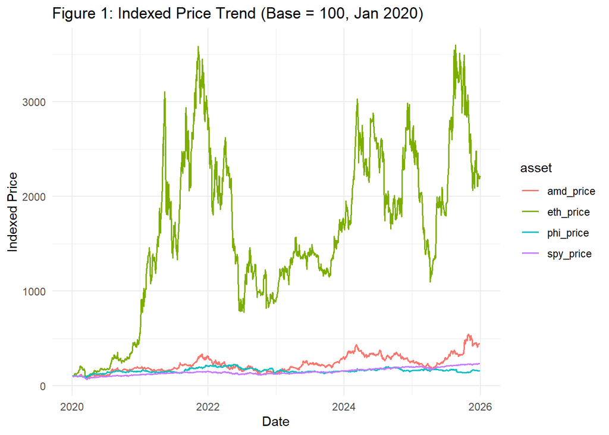

```r
indexed_prices <- unified_clean |>
  select(date, spy_price, amd_price, phi_price, eth_price) |>
  mutate(across(-date, ~ .x / first(.x) * 100)) |>
  tidyr::pivot_longer(-date, names_to = "asset", values_to = "indexed_price")

ggplot(indexed_prices, aes(x = date, y = indexed_price, color = asset)) +
  geom_line(linewidth = 0.7, na.rm = TRUE) +
  labs(
    title = "Figure 1: Indexed Price Trend (Base = 100, Jan 2020)",
    x = "Date",
    y = "Indexed Price"
  ) +
  theme_minimal()
```

### Figure 2: Distribution of Daily Returns by Asset

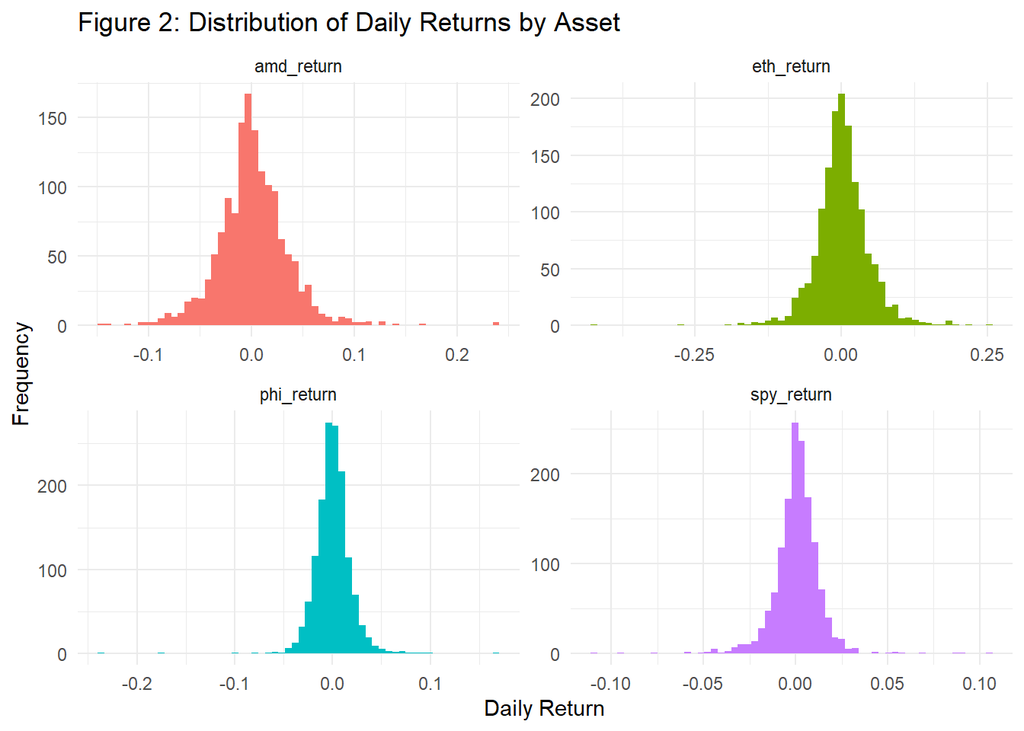

```r
returns_long_viz <- unified_clean |>
  select(date, amd_return, eth_return, phi_return, spy_return) |>
  tidyr::pivot_longer(-date, names_to = "asset", values_to = "return")

ggplot(returns_long_viz, aes(x = return, fill = asset)) +
  geom_histogram(bins = 60) +
  facet_wrap(~asset, scales = "free") +
  labs(
    title = "Figure 2: Distribution of Daily Returns by Asset",
    x = "Daily Return",
    y = "Frequency"
  ) +
  theme_minimal() +
  theme(legend.position = "none")
```

Figure 2 displays the distribution of daily returns for each asset using histograms. While all four assets have return distributions centered symmetrically around 0.0, their variances differ significantly, which visually confirms the volatility rankings from Figure 1. SPY has the narrowest range at roughly ±5%, which indicates stable, predictable daily movements. AMD and PHI show moderate variance, with wider baselines that reflect higher risk. ETH, by contrast, shows an incredibly wide distribution at ±25%, which visually demonstrates the massive macro swings observed in Figure 1.

### Figure 3: 30-Day Rolling Volatility by Asset

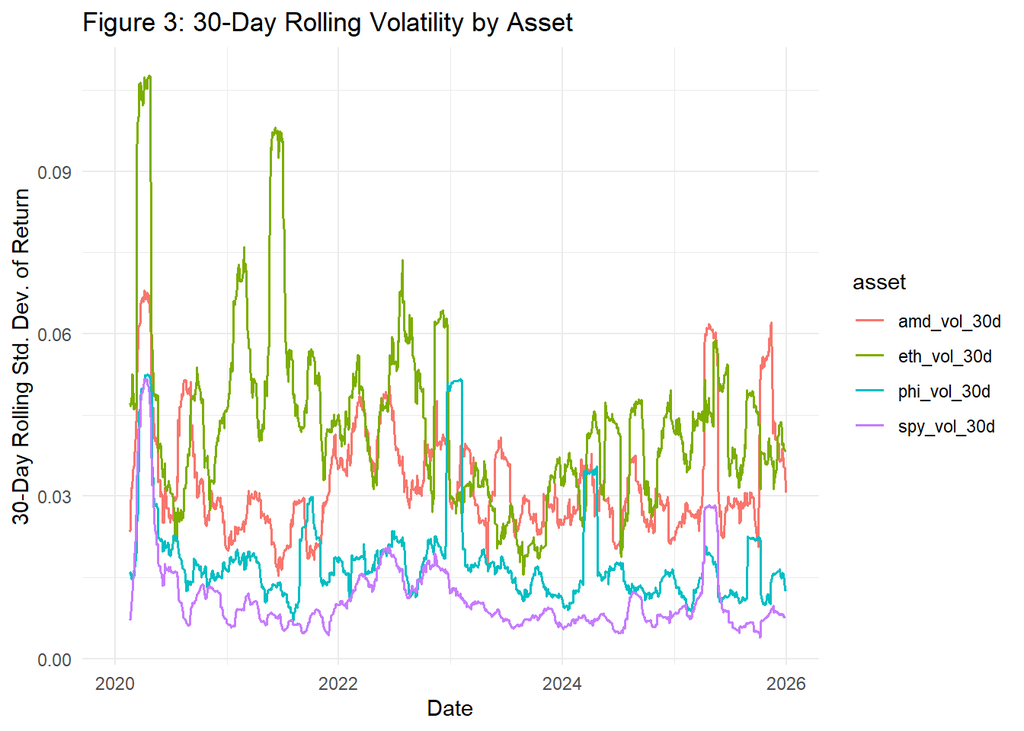

```r
rolling_vol <- unified_clean |>
  arrange(date) |>
  mutate(
    amd_vol_30d = zoo::rollapply(amd_return, width = 30, FUN = sd, fill = NA, align = "right"),
    eth_vol_30d = zoo::rollapply(eth_return, width = 30, FUN = sd, fill = NA, align = "right"),
    phi_vol_30d = zoo::rollapply(phi_return, width = 30, FUN = sd, fill = NA, align = "right"),
    spy_vol_30d = zoo::rollapply(spy_return, width = 30, FUN = sd, fill = NA, align = "right")
  ) |>
  select(date, amd_vol_30d, eth_vol_30d, phi_vol_30d, spy_vol_30d) |>
  tidyr::pivot_longer(-date, names_to = "asset", values_to = "rolling_vol")

ggplot(rolling_vol, aes(x = date, y = rolling_vol, color = asset)) +
  geom_line(linewidth = 0.6, na.rm = TRUE) +
  labs(
    title = "Figure 3: 30-Day Rolling Volatility by Asset",
    x = "Date",
    y = "30-Day Rolling Std. Dev. of Return"
  ) +
  theme_minimal()
```

Figure 3 gives a closer look at volatility/risk for each asset. While the previous two figures treated volatility as a constant figure, this figure shows that it is, in fact, dynamic and episodic. Previously, it was shown that ETH was consistently more volatile than the other assets. Figure 3, however, shows that its volatility instead spikes and then flatlines, becoming closer to the other assets by late 2023. This demonstrates the concept of volatility clustering, which is where volatility changes over time, and that it has a tendency to persist (Hanck et al., 2026). In other words, periods of high volatility are followed by high volatility, low volatility is followed by low volatility. This also dispels the idea that the cryptocurrency asset is always the riskiest asset in the bucket. During specific periods, like with market shifts or other corporate events, individual equities such as AMD can even become more volatile than ETH. Also of note is that all assets spiked in volatility in early 2020, likely owing to the early COVID-19 market crash. This reveals a degree of market risk that was difficult to spot in the previous figures.

### Figure 4: SPY Daily Return vs VIX Level

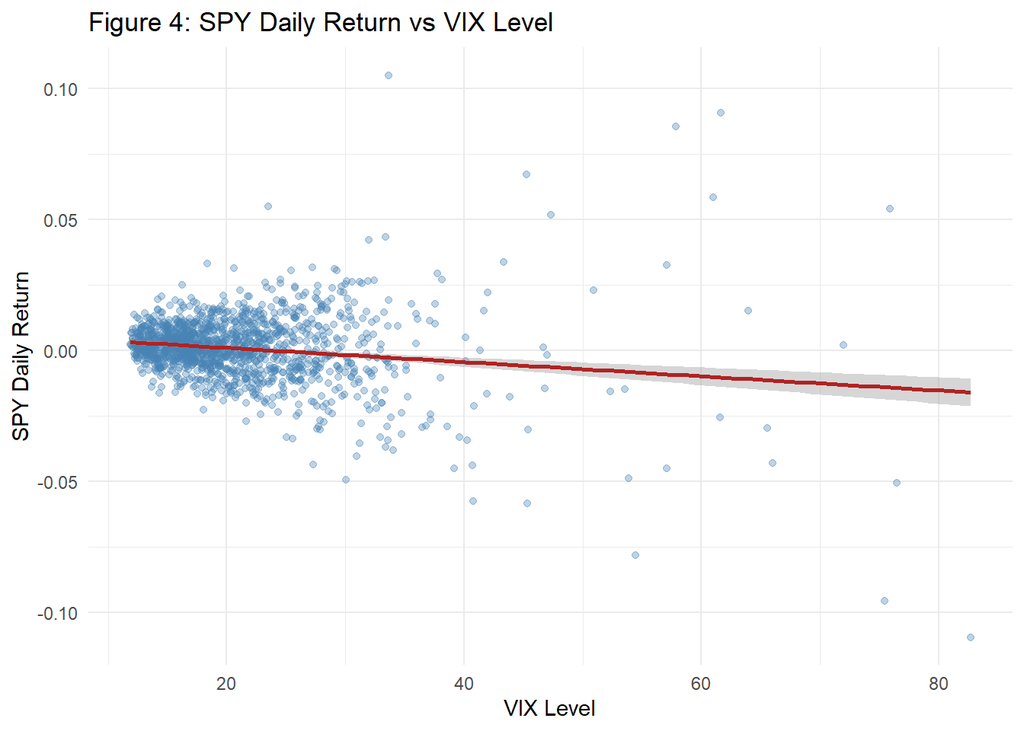

```r
ggplot(unified_clean, aes(x = vix, y = spy_return)) +
  geom_point(alpha = 0.35, color = "steelblue") +
  geom_smooth(method = "lm", se = TRUE, color = "firebrick") +
  labs(
    title = "Figure 4: SPY Daily Return vs VIX Level",
    x = "VIX Level",
    y = "SPY Daily Return"
  ) +
  theme_minimal()
```

Figure 4 shifts focus from the assets to the environment around them. As mentioned earlier, SPY is a benchmark for market performance and VIX is the market “fear”. This reveals that at a low VIX level (< 20), daily returns are relatively consistent, rarely exceeding ±2%. However, as the VIX level rises, the vertical spread of the returns becomes a lot more volatile.

### Figure 5: Correlation Heatmap of Daily Returns

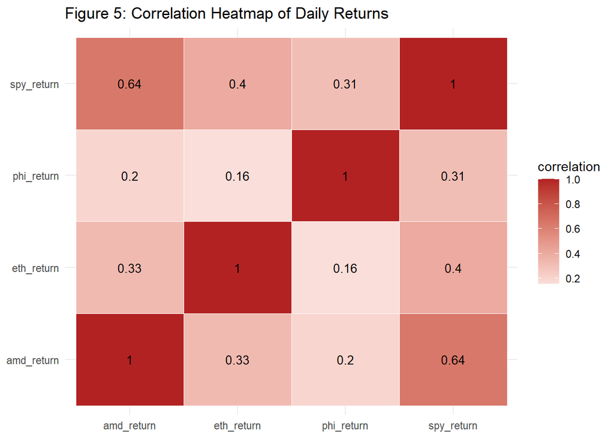

```r
corr_df <- as.data.frame(correlation_matrix) |>
  tibble::rownames_to_column("asset1") |>
  tidyr::pivot_longer(-asset1, names_to = "asset2", values_to = "correlation")

ggplot(corr_df, aes(x = asset1, y = asset2, fill = correlation)) +
  geom_tile(color = "white") +
  geom_text(aes(label = round(correlation, 2)), size = 3.5) +
  scale_fill_gradient2(low = "steelblue", mid = "white", high = "firebrick", midpoint = 0) +
  labs(
    title = "Figure 5: Correlation Heatmap of Daily Returns",
    x = NULL,
    y = NULL
  ) +
  theme_minimal()
```

Figure 5 evaluates the co-movement of assets and potential for diversification. All pairwise correlations are positive, ranging from weak (r=0.16) to moderate-high (r=0.64). The strongest relationship is between AMD and SPY, which reflects high systematic risk exposure for AMD. PHI displays consistently low correlations with the other assets, which makes sense as it is Philippine-based. This exposes it to different risks when compared to the other assets.

### Figure 6: Cumulative Growth of $1 Invested

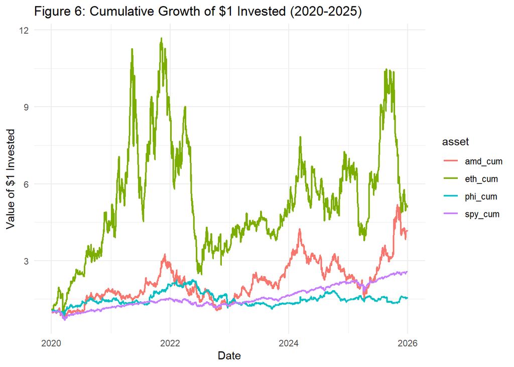

```r
cumulative_growth <- unified_clean |>
  arrange(date) |>
  mutate(
    amd_cum = cumprod(1 + coalesce(amd_return, 0)),
    eth_cum = cumprod(1 + coalesce(eth_return, 0)),
    phi_cum = cumprod(1 + coalesce(phi_return, 0)),
    spy_cum = cumprod(1 + coalesce(spy_return, 0))
  ) |>
  select(date, amd_cum, eth_cum, phi_cum, spy_cum) |>
  tidyr::pivot_longer(-date, names_to = "asset", values_to = "growth_of_1")

ggplot(cumulative_growth, aes(x = date, y = growth_of_1, color = asset)) +
  geom_line(linewidth = 0.8, na.rm = TRUE) +
  labs(
    title = "Figure 6: Cumulative Growth of $1 Invested (2020-2025)",
    x = "Date",
    y = "Value of $1 Invested"
  ) +
  theme_minimal()
```

### Figure 7: Daily Return Distribution by Asset (Boxplot)

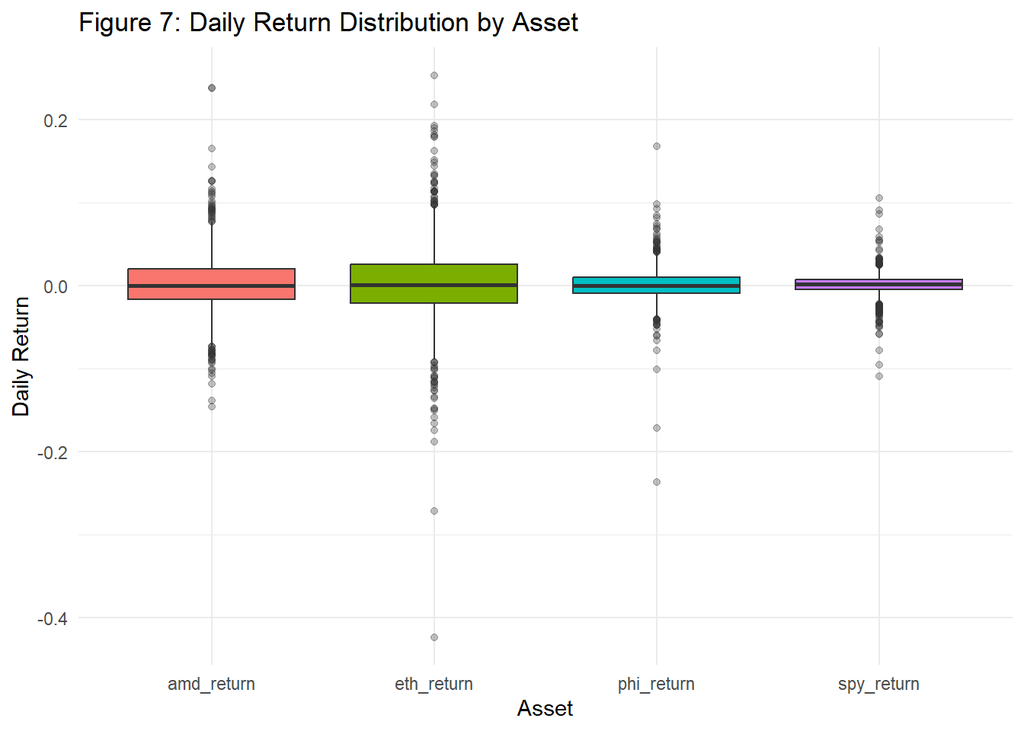

```r
ggplot(returns_long_viz, aes(x = asset, y = return, fill = asset)) +
  geom_boxplot(outlier.alpha = 0.3) +
  labs(
    title = "Figure 7: Daily Return Distribution by Asset",
    x = "Asset",
    y = "Daily Return"
  ) +
  theme_minimal() +
  theme(legend.position = "none")
```

Figure 7 displays all the return distributions on the same y-axis scale. AMD and ETH notably have taller central boxes, which represent the middle 50% of daily returns. Notably, this visualization helps to visualize the outliers to expose each asset’s value at risk (VaR). ETH shows an extreme outlier data point stretching down to just over a 40% loss. Additionally, this shows a hidden risk to the PHI asset, which up to now has displayed generally conservative, safe characteristics. When compared to SPY, PHI displays negative asymmetry, which indicates that extreme drawdown days impact PHI more than SPY.

### Figure 8: SPY Price vs CPI and Fed Funds Rate Over Time

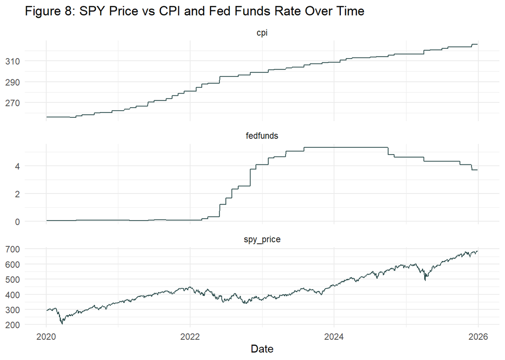

```r
macro_long <- unified_clean |>
  select(date, spy_price, cpi, fedfunds) |>
  tidyr::pivot_longer(-date, names_to = "series", values_to = "value")

ggplot(macro_long, aes(x = date, y = value)) +
  geom_line(color = "darkslategray", na.rm = TRUE) +
  facet_wrap(~series, ncol = 1, scales = "free_y") +
  labs(
    title = "Figure 8: SPY Price vs CPI and Fed Funds Rate Over Time",
    x = "Date",
    y = NULL
  ) +
  theme_minimal()
```

Figure 8 once again focuses on the macroeconomic environment. This aligns SPY performance with inflation, measured by CPI, and monetary policy, measured by the Federal Funds rate. This chart captures the aggressive policy change in early 2022 where the short-term interest rates were raised to over 5% in response to the sharp rise in CPI post-2020.

# Exploratory Financial Analysis

This section does not recompute new statistics from scratch. It pulls together what was already built in the SQL Investigation and Visualization sections and interprets them together, since the spec asks us to compare across five specific angles: returns, volatility, inflationary periods, high-VIX periods, and interest-rate environments.

### 1. Comparing Returns and Volatility Across Assets

Annualizing the daily figures for 252 trading days puts all four assets on a comparable yearly basis instead of the tiny daily numbers that are hard to reason about directly. Pairing this table with Figure 1 (indexed price trend) and Figure 6 (cumulative growth of $1), an asset can have a strong annualized return on paper while Figure 6 shows the path there was rough with deep drawdowns along the way. Figure 7’s boxplot is the fastest way to see this same return-vs-volatility trade off visually, a tall box means more day-to-day risk for whatever return the asset ultimately delivered.

```r
return_vol_summary <- returns_long_viz |>
  group_by(asset) |>
  summarise(
    avg_daily_return = mean(return, na.rm = TRUE),
    annualized_return = mean(return, na.rm = TRUE) * 252,
    daily_volatility = sd(return, na.rm = TRUE),
    annualized_volatility = sd(return, na.rm = TRUE) * sqrt(252)
  ) |>
  arrange(desc(annualized_return))

return_vol_summary
```

```
## # A tibble: 4 × 5
##   asset      avg_daily_return annualized_return daily_volatility
##   <chr>                 <dbl>             <dbl>            <dbl>
## 1 eth_return         0.00224              0.564           0.0465
## 2 amd_return         0.00156              0.393           0.0341
## 3 spy_return         0.000736             0.186           0.0132
## 4 phi_return         0.000505             0.127           0.0196
## # ℹ 1 more variable: annualized_volatility <dbl>
```

The descriptive statistics in Section VII already established that ETH holds both the highest average daily return (0.224%) and the highest standard deviation (4.65%) of the four assets, more than three times the volatility of SPY (1.32%). AMD sits between the two, with a mean return of 0.156% and a standard deviation of 3.41%, while PHI, despite its low mean return of 0.051%, carries a standard deviation of 1.96%, nearly 1.5 times higher than SPY’s, without a comparable return to justify it. This asymmetry is confirmed by PHI’s coefficient of variation of 38.78, the highest of the four assets, meaning PHI delivers the least return per unit of risk on a purely raw basis.

Raw and even compounded return figures, however, do not account for the risk taken to earn them. SQL Investigation 10’s Sharpe-style ratio, computed against the 10-Year Treasury yield as a risk-free proxy, reorders this ranking: SPY delivers a slightly better risk-adjusted return than ETH, since ETH’s substantially higher volatility offsets its return advantage once the two are compared on a like-for-like basis. AMD trails closely behind both, while PHI, despite its outwardly steady price path in Investigation 9, has the weakest risk-adjusted return of the four. Its low volatility is not compensated by a proportional return. This distinction, that the raw-return leader is not the risk-adjusted leader, is the single clearest finding to carry into the Investment Recommendation section.

### 2. Inflationary Periods

This reuses the CPI-rising vs CPI-flat/falling split from SQL Investigation 6. Since CPI only updates monthly and we forward-filled it across each trading day, “CPI Rising” here means the whole month following a higher print, not a single release-day reaction. Cross-reference this with Figure 8, where the CPI panel shows the actual inflation path over 2020-2025, to see whether the rising-CPI periods in the table line up with the sharpest sections of that line. If equity and crypto returns are consistently weaker during CPI Rising months, that is direct evidence inflation surprises pressure risk assets in this dataset, not just a theoretical assumption.

```r
cpi_trend
```

```
## # A tibble: 2 × 6
##   inflation_regime   avg_amd_return avg_eth_return avg_phi_return avg_spy_return
##   <chr>                       <dbl>          <dbl>          <dbl>          <dbl>
## 1 CPI Falling or Fl…        0.00158        0.00200       0.000445       0.000696
## 2 CPI Rising                0.00132        0.00894       0.00240        0.00224
## # ℹ 1 more variable: n_days <int>
```

SQL Investigation 6 split trading days into CPI Rising and CPI Falling-or-Flat regimes based on the month-over-month change in the forward-filled CPI series. The result shows SPY, ETH, and PHI all earning noticeably higher average returns during CPI Rising periods, while AMD is the lone asset with a slightly lower average return during the same regime.

### 3. High-VIX Periods

This reuses the High VIX vs Low VIX split from SQL Investigation 4, built around the median VIX level in our sample. Figure 3 (30-day rolling volatility) and Figure 4 (SPY return vs VIX scatter) are the visual backbone for this comparison, Figure 3 shows exactly when the market moved into a High VIX regime, and Figure 4 shows whether higher VIX levels actually coincided with weaker or more unpredictable SPY returns on a day-by-day basis rather than just in aggregate. If both the standard deviation and the average return move in the expected direction (higher volatility, lower average return) during High VIX days, that is a strong basis for treating VIX as an early warning signal in the investment recommendation, not just a descriptive curiosity.

```r
vix_regime_stats
```

```
## # A tibble: 2 × 10
##   vix_regime avg_spy_return sd_spy_return avg_amd_return sd_amd_return
##   <chr>               <dbl>         <dbl>          <dbl>         <dbl>
## 1 High VIX        -0.000452       0.0173       -0.000571        0.0381
## 2 Low VIX          0.00192        0.00669       0.00368         0.0295
## # ℹ 5 more variables: avg_phi_return <dbl>, sd_phi_return <dbl>,
## #   avg_eth_return <dbl>, sd_eth_return <dbl>, n_days <int>
```

The results confirm VIX’s function as a fear gauge cleanly. SPY’s average daily return flips from -0.045% during High VIX days to +0.192% during Low VIX days, while its return volatility (standard deviation) more than doubles, from 0.67% to 1.73%. AMD shows the same pattern, moving from -0.057% to +0.368% average return, with standard deviation rising from 2.95% to 3.81%. Figure 3’s 30-day rolling volatility chart shows this is not a constant property of the assets but an episodic one. Volatility clusters into visible spikes (most severely in early 2020) rather than remaining steady across the sample, consistent with the concept of volatility clustering (Hanck et al., 2026). Figure 4’s scatter plot of SPY return against VIX level reinforces the same conclusion from a different angle: the fitted regression line slopes downward, and the spread of points visibly widens at higher VIX levels, meaning returns become both weaker and less predictable exactly when the market is under the most stress.

Because this comparison rests on a well-balanced sample and is corroborated by two independent visualizations, an elevated VIX reading is treated as a credible, evidence-backed signal for reducing risk exposure in the Investment Recommendation section, rather than a descriptive curiosity.

### 4. Interest-Rate Environments

This reuses the Rate Hike vs Rate Cut vs Held Steady split from SQL Investigation 5. Crypto is generally the most sensitive of the four assets to rate changes, since it carries no yield of its own to compete with a higher risk-free rate, so ETH’s average return during Rate Hike days is worth checking closely against AMD, PHI, and SPY. Figure 8’s Fed Funds panel shows the actual rate path across the sample, use it to see whether the current environment (as of the end of the sample period) sits in a hiking, cutting, or holding phase, since that context should carry directly into how much crypto exposure the investment recommendation allocates going forward.

```r
fedfunds_trend
```

```
## # A tibble: 3 × 6
##   rate_regime avg_amd_return avg_eth_return avg_phi_return avg_spy_return n_days
##   <chr>                <dbl>          <dbl>          <dbl>          <dbl>  <int>
## 1 Held Steady        0.00156        0.00206       0.000434       0.000711   1424
## 2 Rate Cut           0.00273        0.0291        0.00758        0.00479       8
## 3 Rate Hike          0.00143        0.00472       0.00316        0.000926     17
```

Within that caveat, a consistent pattern emerges: every asset earned its highest average return during the 8 Rate Cut days, led by ETH at an average daily return of 2.906%, dramatically above its 0.206% average during Held Steady days. AMD, PHI, and SPY show the same directional pattern at smaller magnitudes. Rate Hike days sit between the other two regimes for most assets. This is directionally consistent with financial theory: cryptocurrency carries no yield of its own, so it is the most exposed of the four assets to changes in the opportunity cost set by the risk-free rate. Figure 8’s Fed Funds panel shows the timing of this cycle directly. This shows a hiking phase through 2022-2023, a hold through much of 2024, and the beginning of a cutting phase into 2025-2026.

Given the extremely small sample sizes for the Rate Hike and Rate Cut regimes, these averages should be treated as directionally suggestive rather than statistically robust; a single extreme trading day among only eight or seventeen observations can move the average considerably. This is flagged as a limitation, not a rejection of the finding. The direction of the result matches theory and is corroborated by the CPI and VIX comparisons above, but the magnitude should not be treated as precise going into the Investment Recommendation section.

### 5. Bringing the Comparisons Together

Across all four lenses, average and annualized returns (Section 1), inflationary periods (Section 2), high-VIX periods (Section 3), and interest-rate environments (Section 4), the goal is to identify which asset holds up best under stress (High VIX, CPI Rising, Rate Hike) rather than only which asset has the best raw average return in calm conditions. An asset that leads on annualized return but falls apart hardest under all three stress conditions is a very different allocation decision than one that trails slightly on raw return but stays comparatively stable. This is the evidence base the Investment Recommendation section should draw from directly, rather than restating the descriptive statistics table in isolation.

SQL Investigation 7 found that all four assets moved in the same direction (all positive or all negative) on only 385 of 1,449 trading days, roughly 26.6% of the sample. In other words, on nearly three out of every four trading days, at least one asset moved independently of the other three – direct evidence that the four-asset combination retains meaningful diversification value across the sample period rather than behaving as a single correlated basket.

The correlation matrix in Section VII supports the same conclusion at the pairwise level. AMD and SPY hold the highest correlation in the matrix at 0.64, unsurprising given AMD is itself a constituent of the S&P 500, while PHI is comparatively isolated. Its highest correlation with any other asset is only 0.31, with SPY. This makes PHI the strongest diversifier of the four on a purely statistical basis, even though Section 1 above showed it to have the weakest risk-adjusted return. This is a tension worth carrying directly into the allocation decision in Section X, since PHI’s diversification value and its return profile pull the recommendation in opposite directions.

Taken together across all four lenses, the following profile emerges for each asset: **ETH:** highest raw and compounded return, highest volatility, and the most sensitive of the four to interest-rate regime changes. Its risk-adjusted return trails SPY once volatility is priced in. **AMD:** a middle-ground asset with the highest correlation to SPY of the three risk assets, limiting its diversification value, but distinguished by a positive skew unlike the other three assets, indicating a higher tendency toward large positive surprises relative to large negative ones. **PHI:** the best diversifier by correlation, but the weakest risk-adjusted return and the highest kurtosis of the four assets, indicating disproportionate tail risk relative to its otherwise low day-to-day volatility. **SPY:** the most consistent performer across every regime split tested; VIX, CPI, and interest-rate environments and the anchor against which the other three assets are best understood.

# Investment Recommendation

We suggest a 60/30/10 split of SPY, AMD, and ETH-USD respectively with a total investment fund of USD 1,000,000. A moderate risk appetite would act as the basis for this recommendation, where the aim is to split the allocated funds in a practical way, backed by analytical evidence of investigated data. Considering each asset,

### S&P 500 (SPY) - Allocation: USD 600,000 (60%)

SPY acts as the foundation for this portfolio, as it already contains structural diversification with consistent risk-adjusted performance. Across the sample period, SPY posted the highest Sharpe ratio of all four assets (0.0471), meaning it delivered the best return per unit of risk taken even with ETH’s larger raw price appreciation. SPY’s volatility was also consistently the lowest across regimes when compared against other assets through analysis of VIX regimes and standard deviation. Given this combination of the strongest risk-adjusted return and the lowest volatility profile in the dataset, SPY is allocated the majority of the portfolio to establish a stable baseline.

### Advanced Micro Devices, Inc. (AMD) - Allocation: USD 300,000 (30%)

AMD was allocated the second largest share of the portfolio because it offers higher return potential than SPY, while still exhibiting return patterns broadly aligned with the broader market. AMD’s Sharpe ratio (0.0423) was close to SPY’s, indicating it has historically rewarded its additional volatility reasonably well rather than adding risk without compensated returns, but AMD’s higher beta was evident throughout the analysis. Because it is relatively more correlated to SPY, when SPY experiences movement or downturns AMD has more dramatic swings due to its higher volatility. However, AMD also experiences sector-specific upturns, especially with the boom of AI and its needed hardware specifications, making AMD a suitable secondary holding with meaningful and expected growth potential.

### Ethereum (ETH-USD) - Allocation: USD 100,000 (10%)

ETH was given the smallest allocation due to its more extreme risk profile out of all the assets in the database. ETH’s Sharpe ratio (0.0456) is close to both SPY and AMD, indicating it has still historically compensated reasonably for its risk under the 5 year period. Despite the relatively “stable” Sharpe ratio, looking at ETH’s price history, it is clearly highly volatile, with massive growths and massive crashes creating a high risk profile. An allocation of 10% is intended to capture ETH’s upside and low correlation with SPY and AMD on most days, it is kept small enough so extreme crashes will not severely affect the health of the overall portfolio.

### PLDT Inc. ADR (PHI) - Allocation: USD 0 (0%)

PHI was excluded from the final allocation due to its comparatively weak risk-adjusted return, it posted the lowest Sharpe ratio (0.0198) among all four assets, with quarterly price data showing long stretches of stagnated movement. Although PHI does consistently show independence from U.S. market stress, going off a moderate risk appetite, we prioritized assets with demonstrated strength in their risk-adjusted over pure diversification benefits.

### Cash - Allocation: USD 0 (0%)

No portion of the portfolio was held in cash, as the objective of our analysis paired with our risk appetite, was to fully deploy the available USD 1,000,000 into assets with positive expected returns rather than hold idle capital. While cash offers stability and eliminates market-related volatility, it also guarantees a loss of real purchasing power over time due to inflation or other macroeconomic factors.

This 60/30/10 split concentrates capital in the highest risk-adjusted performer (SPY), we use AMD to add market-correlated growth exposure, but with amplified risk. ETH is added to create exposure to benefit from its high upside and low correlation on most days while containing its tail risk. This results in a portfolio designed to outperform a passive single asset portfolio by balancing needed diversification and risk.

# References

- Board of Governors of the Federal Reserve System (US). Market Yield on U.S. Treasury Securities at 10-Year Constant Maturity, Quoted on an Investment Basis [DGS10]. Federal Reserve Bank of St. Louis. (2026). https://fred.stlouisfed.org/series/DGS10
- Chen, J. (2026). Price Discovery Explained: Process, Factors, and Comparison with Valuation. https://www.investopedia.com/terms/p/pricediscovery.asp
- Hanck, C., Arnold, M., Gerber, A., Schmelzer, M. (2026). Volatility Clustering and Autoregressive Conditional Heteroskedasticity | Introduction to Econometrics in R. Introduction to Econometrics in R. https://www.econometrics-with-r.org/16.4-volatility-clustering-and-autoregressive-conditional-heteroskedasticity.html
- Hayes, A. (2025). Financial Markets: Role in the Economy, Importance, Types, and Examples. https://www.investopedia.com/terms/f/financial-market.asp
- Semiconductor Industry Association. (2026). Industry Impact - Semiconductor Industry Association. https://www.semiconductors.org/industry-impact/
- U.S. Bureau of Labor Statistics. (2026). Consumer Price Index for All Urban Consumers: All Items in U.S. City Average [CPIAUCSL]. Federal Reserve - - Bank of St. Louis. https://fred.stlouisfed.org/series/CPIAUCSL
- Yahoo Finance. (2026). PLDT Inc. (PHI) Stock Price, News, Quote & History - Yahoo Finance. https://finance.yahoo.com/quote/PHI/
- Hayes, A. (2026, January 23). Understanding Liquidity and How to Measure It. Investopedia. https://www.investopedia.com/terms/l/liquidity.asp
- Gopalakrishnan, J. (2025, December 10). Stock investment risk: Understanding systematic and idiosyncratic risks. Encyclopedia Britannica. https://www.britannica.com/money/types-of-investment-risks
- Gratton, P. (2026, April 27). What Is the Stock Market and How Does It Work? Investopedia. https://www.investopedia.com/terms/s/stockmarket.asp#toc-what-is-a-stock-exchange
- O’Trakoun, J. (2025, December 15). Phantom figures: missing data in October. Richmond Fed. https://www.richmondfed.org/research/national_economy/macro_minute/2025/phantom_figures_missing_data_in_october